```python
import pandas as pd
import seaborn as sns
import matplotlib.pyplot as plt
import numpy as np
from datetime import datetime, date
import warnings
warnings.filterwarnings('ignore')
pd.set_option('display.max_column', 162)
pd.set_option('display.max_row', 162)
```

# Contexte

L'agence **Santé publique France** a lancé un appel à projets pour trouver des idées innovantes d’applications en lien avec l'alimentation. Vous souhaitez y participer et proposer une idée d’application.

# Objectif

- Trouver une idée d’application : sélection des variables pertinentes
- Traitement des données ( imputation, gestion des valeurs aberrantes / manquantes)
- Automatisant des traitements.
- Tests hypothèses et analyses exploratoires
- Identifier des arguments justifiant la faisabilité (ou non) de l’application à partir des données Open Food Facts.
- Rédiger un rapport d’exploration et pitcher votre idée durant la soutenance du projet.

Chargez le fichier `fr.openfoodfacts.org.products.csv` à l'aide de Pandas. Stockez le résultat du chargement dans la variable `df`.

```python
df = pd.read_csv('fr.openfoodfacts.org.products.csv', sep='\t')
```

# Les données

## Compréhension des données

Afficher les 5 premières lignes du dataframe `df`.

```python
df.head()
```

|  | code | url | creator | created_t | created_datetime | last_modified_t | last_modified_datetime | product_name | generic_name | quantity | packaging | packaging_tags | brands | brands_tags | categories | categories_tags | categories_fr | origins | origins_tags | manufacturing_places | manufacturing_places_tags | labels | labels_tags | labels_fr | emb_codes | emb_codes_tags | first_packaging_code_geo | cities | cities_tags | … |
| --- | --- | --- | --- | --- | --- | --- | --- | --- | --- | --- | --- | --- | --- | --- | --- | --- | --- | --- | --- | --- | --- | --- | --- | --- | --- | --- | --- | --- | --- | --- |
| 0 | 3087 | http://world-fr.openfoodfacts.org/produit/0000... | openfoodfacts-contributors | 1474103866 | 2016-09-17T09:17:46Z | 1474103893 | 2016-09-17T09:18:13Z | Farine de blé noir | NaN | 1kg | NaN | NaN | Ferme t'y R'nao | ferme-t-y-r-nao | NaN | NaN | NaN | NaN | NaN | NaN | NaN | NaN | NaN | NaN | NaN | NaN | NaN | NaN | NaN | … |
| 1 | 4530 | http://world-fr.openfoodfacts.org/produit/0000... | usda-ndb-import | 1489069957 | 2017-03-09T14:32:37Z | 1489069957 | 2017-03-09T14:32:37Z | Banana Chips Sweetened (Whole) | NaN | NaN | NaN | NaN | NaN | NaN | NaN | NaN | NaN | NaN | NaN | NaN | NaN | NaN | NaN | NaN | NaN | NaN | NaN | NaN | NaN | … |
| 2 | 4559 | http://world-fr.openfoodfacts.org/produit/0000... | usda-ndb-import | 1489069957 | 2017-03-09T14:32:37Z | 1489069957 | 2017-03-09T14:32:37Z | Peanuts | NaN | NaN | NaN | NaN | Torn & Glasser | torn-glasser | NaN | NaN | NaN | NaN | NaN | NaN | NaN | NaN | NaN | NaN | NaN | NaN | NaN | NaN | NaN | … |
| 3 | 16087 | http://world-fr.openfoodfacts.org/produit/0000... | usda-ndb-import | 1489055731 | 2017-03-09T10:35:31Z | 1489055731 | 2017-03-09T10:35:31Z | Organic Salted Nut Mix | NaN | NaN | NaN | NaN | Grizzlies | grizzlies | NaN | NaN | NaN | NaN | NaN | NaN | NaN | NaN | NaN | NaN | NaN | NaN | NaN | NaN | NaN | … |
| 4 | 16094 | http://world-fr.openfoodfacts.org/produit/0000... | usda-ndb-import | 1489055653 | 2017-03-09T10:34:13Z | 1489055653 | 2017-03-09T10:34:13Z | Organic Polenta | NaN | NaN | NaN | NaN | Bob's Red Mill | bob-s-red-mill | NaN | NaN | NaN | NaN | NaN | NaN | NaN | NaN | NaN | NaN | NaN | NaN | NaN | NaN | NaN | … |

Quelle est la taille du dataframe ?

```python
df.shape
```

```
(320772, 162)
```

Calculez les statistiques élémentaires (min, max, moyenne, écart type, etc) pour toutes les variables quantitatives.

```python
df.describe()
```

|  | no_nutriments | additives_n | ingredients_from_palm_oil_n | ingredients_from_palm_oil | ingredients_that_may_be_from_palm_oil_n | ingredients_that_may_be_from_palm_oil | nutrition_grade_uk | energy_100g | energy-from-fat_100g | fat_100g | saturated-fat_100g | butyric-acid_100g | caproic-acid_100g | caprylic-acid_100g | capric-acid_100g | lauric-acid_100g | myristic-acid_100g | palmitic-acid_100g | stearic-acid_100g | arachidic-acid_100g | behenic-acid_100g | lignoceric-acid_100g | cerotic-acid_100g | montanic-acid_100g | melissic-acid_100g | monounsaturated-fat_100g | polyunsaturated-fat_100g | omega-3-fat_100g | alpha-linolenic-acid_100g | … |
| --- | --- | --- | --- | --- | --- | --- | --- | --- | --- | --- | --- | --- | --- | --- | --- | --- | --- | --- | --- | --- | --- | --- | --- | --- | --- | --- | --- | --- | --- | --- |
| count | 0.0 | 248939.000000 | 248939.000000 | 0.0 | 248939.000000 | 0.0 | 0.0 | 2.611130e+05 | 857.000000 | 243891.000000 | 229554.000000 | 0.0 | 0.0 | 1.0 | 2.000000 | 4.000000 | 1.0 | 1.0 | 1.0 | 24.000000 | 23.000000 | 0.0 | 0.0 | 1.0 | 0.0 | 22823.000000 | 22859.000000 | 841.000000 | 186.000000 | … |
| mean | NaN | 1.936024 | 0.019659 | NaN | 0.055246 | NaN | NaN | 1.141915e+03 | 585.501214 | 12.730379 | 5.129932 | NaN | NaN | 7.4 | 6.040000 | 36.136182 | 18.9 | 8.1 | 3.0 | 10.752667 | 10.673913 | NaN | NaN | 61.0 | NaN | 10.425055 | 6.312493 | 3.182103 | 2.250285 | … |
| std | NaN | 2.502019 | 0.140524 | NaN | 0.269207 | NaN | NaN | 6.447154e+03 | 712.809943 | 17.578747 | 8.014238 | NaN | NaN | NaN | 0.226274 | 24.101433 | NaN | NaN | NaN | 4.019993 | 3.379647 | NaN | NaN | NaN | NaN | 17.076167 | 10.832591 | 5.607988 | 7.971418 | … |
| min | NaN | 0.000000 | 0.000000 | NaN | 0.000000 | NaN | NaN | 0.000000e+00 | 0.000000 | 0.000000 | 0.000000 | NaN | NaN | 7.4 | 5.880000 | 0.044730 | 18.9 | 8.1 | 3.0 | 0.064000 | 5.200000 | NaN | NaN | 61.0 | NaN | 0.000000 | 0.000000 | 0.000000 | 0.000000 | … |
| 25% | NaN | 0.000000 | 0.000000 | NaN | 0.000000 | NaN | NaN | 3.770000e+02 | 49.400000 | 0.000000 | 0.000000 | NaN | NaN | 7.4 | 5.960000 | 34.661183 | 18.9 | 8.1 | 3.0 | 7.275000 | 7.100000 | NaN | NaN | 61.0 | NaN | 0.000000 | 0.000000 | 0.600000 | 0.068750 | … |
| 50% | NaN | 1.000000 | 0.000000 | NaN | 0.000000 | NaN | NaN | 1.100000e+03 | 300.000000 | 5.000000 | 1.790000 | NaN | NaN | 7.4 | 6.040000 | 47.600000 | 18.9 | 8.1 | 3.0 | 12.850000 | 12.600000 | NaN | NaN | 61.0 | NaN | 4.000000 | 2.220000 | 1.800000 | 0.117500 | … |
| 75% | NaN | 3.000000 | 0.000000 | NaN | 0.000000 | NaN | NaN | 1.674000e+03 | 898.000000 | 20.000000 | 7.140000 | NaN | NaN | 7.4 | 6.120000 | 49.075000 | 18.9 | 8.1 | 3.0 | 13.375000 | 13.050000 | NaN | NaN | 61.0 | NaN | 10.710000 | 7.140000 | 3.200000 | 0.604000 | … |
| max | NaN | 31.000000 | 2.000000 | NaN | 6.000000 | NaN | NaN | 3.251373e+06 | 3830.000000 | 714.290000 | 550.000000 | NaN | NaN | 7.4 | 6.200000 | 49.300000 | 18.9 | 8.1 | 3.0 | 15.400000 | 14.600000 | NaN | NaN | 61.0 | NaN | 557.140000 | 98.000000 | 60.000000 | 75.000000 | … |

```python
df.columns
```

```
Index(['code', 'url', 'creator', 'created_t', 'created_datetime',
       'last_modified_t', 'last_modified_datetime', 'product_name',
       'generic_name', 'quantity',
       ...
       'ph_100g', 'fruits-vegetables-nuts_100g',
       'collagen-meat-protein-ratio_100g', 'cocoa_100g', 'chlorophyl_100g',
       'carbon-footprint_100g', 'nutrition-score-fr_100g',
       'nutrition-score-uk_100g', 'glycemic-index_100g',
       'water-hardness_100g'],
      dtype='object', length=162)
```

```python
for col in df.columns:
    print(col,df[col].nunique())
```

```
code 320638
url 320749
creator 3535
created_t 189636
created_datetime 189568
last_modified_t 180639
last_modified_datetime 180495
product_name 221347
generic_name 38584
quantity 13826
packaging 14547
packaging_tags 12064
brands 58784
brands_tags 50253
categories 36982
categories_tags 21142
categories_fr 21152
origins 4840
origins_tags 4372
manufacturing_places 7308
manufacturing_places_tags 6736
labels 18114
labels_tags 13653
labels_fr 13655
emb_codes 8462
emb_codes_tags 8158
first_packaging_code_geo 1602
cities 3
cities_tags 2572
purchase_places 5120
stores 3259
countries 1434
countries_tags 725
countries_fr 722
ingredients_text 205520
allergens 12939
allergens_fr 19
traces 8378
traces_tags 3578
traces_fr 3584
```

[output cut: 107 more lines]

```
chromium_100g 17
molybdenum_100g 9
iodine_100g 111
caffeine_100g 42
taurine_100g 17
ph_100g 25
fruits-vegetables-nuts_100g 333
collagen-meat-protein-ratio_100g 6
cocoa_100g 84
chlorophyl_100g 0
carbon-footprint_100g 202
nutrition-score-fr_100g 55
nutrition-score-uk_100g 55
glycemic-index_100g 0
water-hardness_100g 0
```

Une composante dite « négative », calculée à partir des teneurs en nutriments dont la consommation doit être limitée : énergie, sucres simples, acides gras saturésn sel et sodium ;

Une composante dite « positive », calculée en intégrant les teneurs en nutriment dont la consommation est recommandée : fibres, protéines;

Une deuxième composante « positive », calculée à partir des teneurs d’une catégorie spécifique d’aliments : les fruits/légumes/fruits à coque.

**Energie** Les données qui nous interesse sont l’énergie (kJ/100g), la graisse, les gras saturés (g/100g), les sucres simples (g/100g) et le sel (mg/100g)

**Nutritif** des facteurs nutritionnels à favoriser : les fibres (g/100g), les protéines (g/100g), les fruits et légumes, légumineuses et fruits à coque (g/100g)

# Data Cleaning

## Filtre des données

```python
df = df[['created_datetime',
         'countries',
         'creator',
         'product_name',
         'origins',
         'fat_100g',
         'sugars_100g',
         'energy_100g',
         'carbohydrates_100g',
         'saturated-fat_100g',
         'fiber_100g',
         'proteins_100g',
         'salt_100g',
         'fruits-vegetables-nuts_100g',
         'nutrition-score-fr_100g',
         'pnns_groups_1',
         'nutrition_grade_fr']]
```

```python
df.info()
```

```
<class 'pandas.core.frame.DataFrame'>
RangeIndex: 320772 entries, 0 to 320771
Data columns (total 17 columns):
 #   Column                       Non-Null Count   Dtype
---  ------                       --------------   -----
 0   created_datetime             320763 non-null  object
 1   countries                    320492 non-null  object
 2   creator                      320770 non-null  object
 3   product_name                 303010 non-null  object
 4   origins                      22190 non-null   object
 5   fat_100g                     243891 non-null  float64
 6   sugars_100g                  244971 non-null  float64
 7   energy_100g                  261113 non-null  float64
 8   carbohydrates_100g           243588 non-null  float64
 9   saturated-fat_100g           229554 non-null  float64
 10  fiber_100g                   200886 non-null  float64
 11  proteins_100g                259922 non-null  float64
 12  salt_100g                    255510 non-null  float64
 13  fruits-vegetables-nuts_100g  3036 non-null    float64
 14  nutrition-score-fr_100g      221210 non-null  float64
 15  pnns_groups_1                91513 non-null   object
 16  nutrition_grade_fr           221210 non-null  object
dtypes: float64(10), object(7)
memory usage: 41.6+ MB
```

## Missing Values

|  | Total | Percent |
| --- | --- | --- |
| fruits-vegetables-nuts_100g | 317736 | 0.990535 |
| origins | 298582 | 0.930823 |
| pnns_groups_1 | 229259 | 0.714710 |
| fiber_100g | 119886 | 0.373742 |
| nutrition_grade_fr | 99562 | 0.310382 |
| nutrition-score-fr_100g | 99562 | 0.310382 |
| saturated-fat_100g | 91218 | 0.284370 |
| carbohydrates_100g | 77184 | 0.240620 |
| fat_100g | 76881 | 0.239675 |
| sugars_100g | 75801 | 0.236308 |
| salt_100g | 65262 | 0.203453 |
| proteins_100g | 60850 | 0.189699 |
| energy_100g | 59659 | 0.185986 |
| product_name | 17762 | 0.055373 |
| countries | 280 | 0.000873 |
| created_datetime | 9 | 0.000028 |
| creator | 2 | 0.000006 |

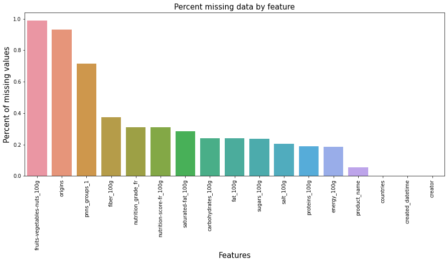

```python
total = df.isnull().sum().sort_values(ascending=False)
percent = (df.isnull().sum()/df.isnull().count()).sort_values(ascending=False)
missing_data = pd.concat([total, percent], axis=1, keys=['Total', 'Percent'])
f, ax = plt.subplots(figsize=(15, 6))
plt.xticks(rotation='90')
sns.barplot(x=missing_data.index, y=missing_data['Percent'])
plt.xlabel('Features', fontsize=15)
plt.ylabel('Percent of missing values', fontsize=15)
plt.title('Percent missing data by feature', fontsize=15)
missing_data
```

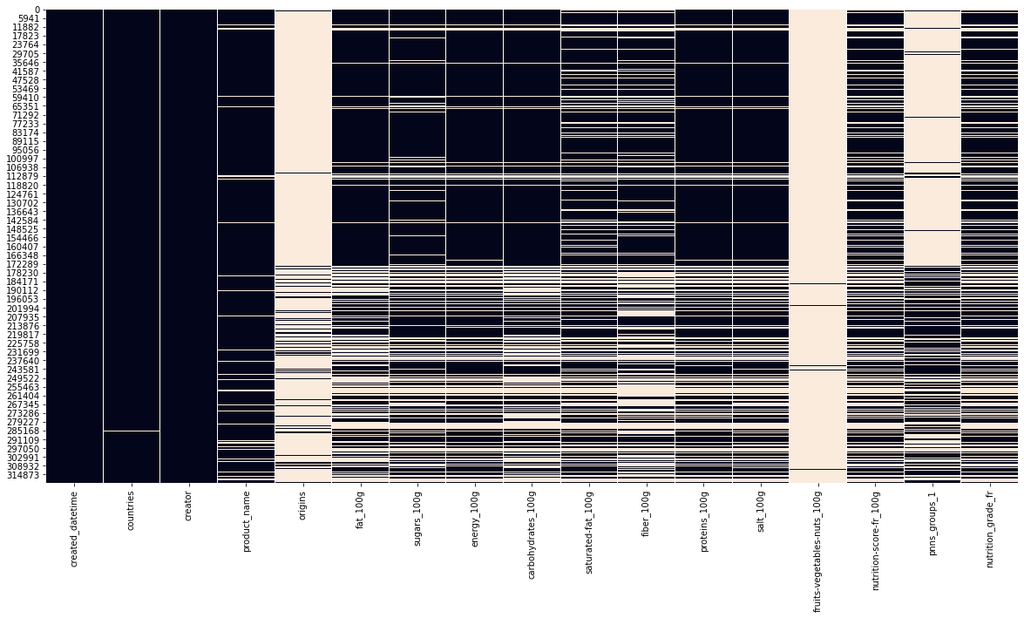

```python
plt.figure(figsize=(20,10))
sns.heatmap(df.isna(), cbar=False)
```

Nayant pas suffisament de données, nous décidons de retirer les features origins et fruits et vegetables, Malheureusement car l'information fruits et vegetables était interessante à exploiter pour le calcul du nutriscore.

```python
#création de missing rate
missing_rate = df.isna().sum()/df.shape[0]
```

```python
missing_rate
```

```
created_datetime               0.000028
countries                      0.000873
creator                        0.000006
product_name                   0.055373
origins                        0.930823
fat_100g                       0.239675
sugars_100g                    0.236308
energy_100g                    0.185986
carbohydrates_100g             0.240620
saturated-fat_100g             0.284370
fiber_100g                     0.373742
proteins_100g                  0.189699
salt_100g                      0.203453
fruits-vegetables-nuts_100g    0.990535
nutrition-score-fr_100g        0.310382
pnns_groups_1                  0.714710
nutrition_grade_fr             0.310382
dtype: float64
```

On fixe un seuil de 90% de valeurs manquantes, nous supprimerons les features avec un taux de missing value au delà

```python
df.drop(df.columns[missing_rate>0.9], axis=1, inplace=True)
```

## Countries Column Filtering

```python
df['countries'] = df['countries'].astype(str)
```

```python
df['countries'].value_counts().index.tolist()
```

```
['US',
 'France',
 'en:FR',
 'Suisse',
 'Deutschland',
 'España',
 'United Kingdom',
 'United States',
 'en:CH',
 'en:BE',
 'en:GB',
 'Australia',
 'en:DE',
 'Россия',
 'en:ES',
 'Belgique',
 'en:US',
 'en:AU',
 'en:IT',
 'en:CA',
 'France, Suisse',
 'Portugal',
 'Germany',
 'Switzerland',
 'Italia',
 'Canada',
 'nan',
 'Nederland',
 'Belgium',
 'Spain',
 'Belgique,France',
 'en:CZ',
 'France,Suisse',
 'en:FR, Suisse',
 'en:AT',
 'en:TH',
 'en:NL',
 'Österreich',
 'Brasil',
 'Magyarország',
```

[output cut: 946 more lines]

```
 'Maroc,France',
 'الجزائر, en:france',
 'France,United Kingdom, US',
 'Marruecos',
 'France, en:algeria',
 'Singapore,New Zealand,Thailand,Australia, US',
 'België,Frankrijk',
 'Espana',
 'Australia, en:india',
 'en:DE, en:denmark, en:france',
 'Belgique, en:denmark, en:france',
 'France,Belgique,Allemagne',
 '日本, en:france',
 'en:PT, en:france, en:belgium, en:spain',
 ...]
```

```python
France = ['France', 'en:FR', 'France, Suisse', 'France,Suisse',
          'France,La Réunion', 'France,Guadeloupe', 'France,Espagne', 'France,Allemagne', 'France,Switzerland',
          'France, US', 'France, en:belgium', 'en:FR, Suisse', 'France,UK', 'UK,France', 'France,United Kingdom',
          'France, en:switzerland','France,Royaume-Uni', 'Belgique, en:france','FR','Francia,España' ]
```

```python
df = df[df['countries'].isin(France)]
```

```python
df["countries"].value_counts()
```

```
France                    77292
en:FR                     16979
France, Suisse              506
France,Suisse               212
en:FR, Suisse               204
France,UK                   135
UK,France                   125
France,United Kingdom       125
France, en:switzerland      116
France,Switzerland           88
France, US                   82
France, en:belgium           80
France,Allemagne             73
France,Royaume-Uni           65
Belgique, en:france          63
France,Espagne               58
France,Guadeloupe            55
France,La Réunion            37
FR                           27
Francia,España               25
Name: countries, dtype: int64
```

```python
df
```

|  | created_datetime | countries | creator | product_name | fat_100g | sugars_100g | energy_100g | carbohydrates_100g | saturated-fat_100g | fiber_100g | proteins_100g | salt_100g | nutrition-score-fr_100g | pnns_groups_1 | nutrition_grade_fr |
| --- | --- | --- | --- | --- | --- | --- | --- | --- | --- | --- | --- | --- | --- | --- | --- |
| 0 | 2016-09-17T09:17:46Z | en:FR | openfoodfacts-contributors | Farine de blé noir | NaN | NaN | NaN | NaN | NaN | NaN | NaN | NaN | NaN | NaN | NaN |
| 46 | 2015-06-17T08:45:04Z | France | date-limite-app | Filet de bœuf | NaN | NaN | NaN | NaN | NaN | NaN | NaN | NaN | NaN | unknown | NaN |
| 48 | 2016-03-17T18:17:10Z | en:FR | tacinte | NaN | NaN | NaN | NaN | NaN | NaN | NaN | NaN | NaN | NaN | NaN | NaN |
| 106 | 2015-01-25T21:35:01Z | France, US | tacinte | Lion Peanut x2 | 20.0 | 57.5 | 1883.0 | 70.0 | 12.5 | 2.5 | 2.5 | 0.09652 | 22.0 | unknown | e |
| 136 | 2015-01-25T21:36:13Z | France | tacinte | Twix x2 | NaN | NaN | NaN | NaN | NaN | NaN | NaN | NaN | NaN | unknown | NaN |
| ... | ... | ... | ... | ... | ... | ... | ... | ... | ... | ... | ... | ... | ... | ... | ... |
| 320761 | 2013-07-10T18:20:08Z | France | agamitsudo | Roussette du Bugey (2011) | NaN | NaN | NaN | NaN | NaN | NaN | NaN | NaN | NaN | NaN | NaN |
| 320763 | 2013-04-28T15:30:39Z | France | balooval | Thé vert Earl grey | 0.2 | 0.5 | 21.0 | 0.5 | 0.2 | 0.2 | 0.5 | 0.02540 | 2.0 | Beverages | c |
| 320764 | 2015-04-27T20:52:34Z | en:FR | woshilapin | Cheese cake thé vert, yuzu | NaN | NaN | NaN | NaN | NaN | NaN | NaN | NaN | NaN | NaN | NaN |
| 320765 | 2015-10-31T12:07:09Z | France | sebleouf | Rillette d'oie | NaN | NaN | NaN | NaN | NaN | NaN | NaN | NaN | NaN | Fish Meat Eggs | NaN |
| 320770 | 2017-04-16T10:54:49Z | en:FR | openfoodfacts-contributors | Tomates aux Vermicelles | NaN | NaN | NaN | NaN | NaN | NaN | NaN | NaN | NaN | NaN | NaN |

96347 rows × 15 columns

## Date Column Filtering

On s'interesse maintenant à la feature Created datetime pour avoir une idée de l'étendue temporelle de nos données (2017 à 2012)

```python
df['created_datetime'] = df['created_datetime'].astype(str)

# Isoler les années avec la fonction split
df["Year"] = df['created_datetime'].apply(
    lambda x: x.split('-')[0])
```

```python
# verification des date unique
df["Year"].nunique()
```

```
7
```

```python
# nombre de dates
df["Year"].value_counts()
```

```
2016    30523
2017    23494
2015    22413
2014     8819
2013     8106
2012     2991
nan         1
Name: Year, dtype: int64
```

On remarque une 'année' correspondant à Nan. Nous eliminons cette ligne de notre dataframe

```python
df[df["Year"]=='nan']
```

|  | created_datetime | countries | creator | product_name | fat_100g | sugars_100g | energy_100g | carbohydrates_100g | saturated-fat_100g | fiber_100g | proteins_100g | salt_100g | nutrition-score-fr_100g | pnns_groups_1 | nutrition_grade_fr | Year |
| --- | --- | --- | --- | --- | --- | --- | --- | --- | --- | --- | --- | --- | --- | --- | --- | --- |
| 187478 | nan | France,Suisse | marianne | Lulu la barquette (Fraise) | 2.1 | 60.0 | 1480.0 | 78.0 | 0.5 | 1.2 | 4.2 | 0.08 | 13.0 | Sugary snacks | d | nan |

```python
df.drop([187478], axis=0, inplace=True)
```

```python
## Visualisation du nombre de donnée par Created datetime
```

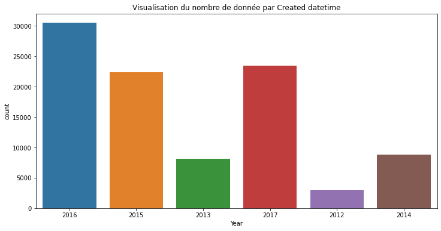

```python
fig = plt.figure(figsize=(12,6))
sns.countplot(x=df["Year"]).set(title='Visualisation du nombre de donnée par Created datetime')
plt.show()
```

Pour notre analyse, notre plus grand contributeur sera openfoodfacts

```python
df['creator'].value_counts()
```

```
openfoodfacts-contributors    28489
kiliweb                       13874
date-limite-app                7772
tacite                         6952
sebleouf                       5509
                              ...
phpinsudarak                      1
danihopera                        1
jennyjen                          1
oldig                             1
cath72                            1
Name: creator, Length: 2537, dtype: int64
```

|  | Total | Percent |
| --- | --- | --- |
| fiber_100g | 51580 | 0.535362 |
| carbohydrates_100g | 50683 | 0.526052 |
| fat_100g | 50259 | 0.521651 |
| nutrition-score-fr_100g | 36338 | 0.377161 |
| nutrition_grade_fr | 36338 | 0.377161 |
| saturated-fat_100g | 35412 | 0.367550 |
| sugars_100g | 35293 | 0.366315 |
| salt_100g | 35242 | 0.365786 |
| proteins_100g | 33573 | 0.348463 |
| energy_100g | 33310 | 0.345733 |
| pnns_groups_1 | 33279 | 0.345411 |
| product_name | 7127 | 0.073973 |
| created_datetime | 0 | 0.000000 |
| countries | 0 | 0.000000 |
| creator | 0 | 0.000000 |
| Year | 0 | 0.000000 |

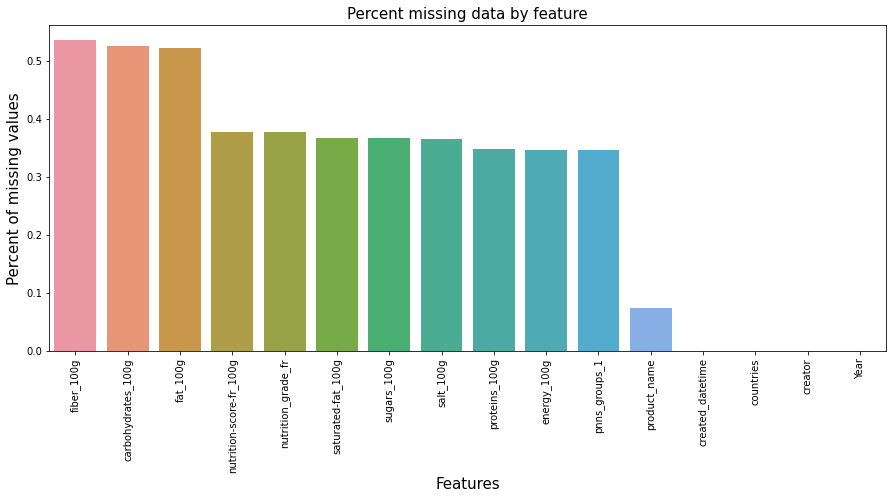

```python
total = df.isnull().sum().sort_values(ascending=False)
percent = (df.isnull().sum()/df.isnull().count()).sort_values(ascending=False)
missing_data = pd.concat([total, percent], axis=1, keys=['Total', 'Percent'])
f, ax = plt.subplots(figsize=(15, 6))
plt.xticks(rotation='90')
sns.barplot(x=missing_data.index, y=missing_data['Percent'])
plt.xlabel('Features', fontsize=15)
plt.ylabel('Percent of missing values', fontsize=15)
plt.title('Percent missing data by feature', fontsize=15)
missing_data
```

## Feature Pnns group1

```python
df['pnns_groups_1'].nunique()
```

```
13
```

```python
df['pnns_groups_1'].value_counts()
```

```
unknown                    12113
Sugary snacks               9005
Fish Meat Eggs              6712
Beverages                   6341
Milk and dairy products     6234
Composite foods             5996
Cereals and potatoes        5887
Fruits and vegetables       4012
Fat and sauces              3709
Salty snacks                2047
fruits-and-vegetables        542
sugary-snacks                467
cereals-and-potatoes           2
Name: pnns_groups_1, dtype: int64
```

```python
df.drop(index=df[df['pnns_groups_1'] == 'unknown'].index, inplace=True)
```

```python
list(pd.unique(df.pnns_groups_1.values))
```

```
[nan,
 'Cereals and potatoes',
 'Sugary snacks',
 'Beverages',
 'Fish Meat Eggs',
 'Composite foods',
 'Fruits and vegetables',
 'Milk and dairy products',
 'Salty snacks',
 'Fat and sauces',
 'fruits-and-vegetables',
 'sugary-snacks',
 'cereals-and-potatoes']
```

```python
df = df.replace("sugary-snacks", "Sugary snacks")
df = df.replace("cereals-and-potatoes", "Cereals and potatoes")
df = df.replace("fruits-and-vegetables", "Fruits and vegetables")
```

```python
list(pd.unique(df.pnns_groups_1.values))
```

```
[nan,
 'Cereals and potatoes',
 'Sugary snacks',
 'Beverages',
 'Fish Meat Eggs',
 'Composite foods',
 'Fruits and vegetables',
 'Milk and dairy products',
 'Salty snacks',
 'Fat and sauces']
```

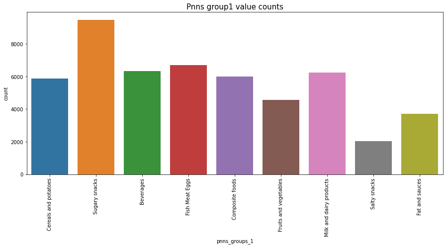

```python
f, ax = plt.subplots(figsize=(15, 6))
plt.xticks(rotation='90')
sns.countplot(data=df, x="pnns_groups_1")
plt.title('Pnns group1 value counts', fontsize=15)
```

## Supression des features

Les features ayant servi au travail de filtrage précedement également seront supprimées pendant cette étape

```python
df.drop(['created_datetime',"creator",'countries','Year'], axis=1,inplace=True)
```

```python
df.shape
```

```
(84233, 12)
```

```python
df.info()
```

```
<class 'pandas.core.frame.DataFrame'>
Int64Index: 84233 entries, 0 to 320770
Data columns (total 12 columns):
 #   Column                   Non-Null Count  Dtype
---  ------                   --------------  -----
 0   product_name             78145 non-null  object
 1   fat_100g                 39477 non-null  float64
 2   sugars_100g              53768 non-null  float64
 3   energy_100g              55446 non-null  float64
 4   carbohydrates_100g       39076 non-null  float64
 5   saturated-fat_100g       53681 non-null  float64
 6   fiber_100g               39594 non-null  float64
 7   proteins_100g            55229 non-null  float64
 8   salt_100g                53803 non-null  float64
 9   nutrition-score-fr_100g  52995 non-null  float64
 10  pnns_groups_1            50954 non-null  object
 11  nutrition_grade_fr       52995 non-null  object
dtypes: float64(9), object(3)
memory usage: 10.4+ MB
```

## Duplicated Values

```python
df[df.duplicated()]
```

|  | product_name | fat_100g | sugars_100g | energy_100g | carbohydrates_100g | saturated-fat_100g | fiber_100g | proteins_100g | salt_100g | nutrition-score-fr_100g | pnns_groups_1 | nutrition_grade_fr |
| --- | --- | --- | --- | --- | --- | --- | --- | --- | --- | --- | --- | --- |
| 227 | NaN | NaN | NaN | NaN | NaN | NaN | NaN | NaN | NaN | NaN | NaN | NaN |
| 280 | NaN | NaN | NaN | NaN | NaN | NaN | NaN | NaN | NaN | NaN | NaN | NaN |
| 339 | NaN | NaN | NaN | NaN | NaN | NaN | NaN | NaN | NaN | NaN | NaN | NaN |
| 432 | NaN | NaN | NaN | NaN | NaN | NaN | NaN | NaN | NaN | NaN | NaN | NaN |
| 435 | NaN | NaN | NaN | NaN | NaN | NaN | NaN | NaN | NaN | NaN | NaN | NaN |
| ... | ... | ... | ... | ... | ... | ... | ... | ... | ... | ... | ... | ... |
| 320745 | NaN | NaN | NaN | NaN | NaN | NaN | NaN | NaN | NaN | NaN | Sugary snacks | NaN |
| 320746 | NaN | NaN | NaN | NaN | NaN | NaN | NaN | NaN | NaN | NaN | Sugary snacks | NaN |
| 320747 | NaN | NaN | NaN | NaN | NaN | NaN | NaN | NaN | NaN | NaN | Sugary snacks | NaN |
| 320755 | NaN | NaN | NaN | NaN | NaN | NaN | NaN | NaN | NaN | NaN | Sugary snacks | NaN |
| 320760 | Poireaux | NaN | NaN | NaN | NaN | NaN | NaN | NaN | NaN | NaN | NaN | NaN |

9083 rows × 12 columns

```python
# combien de valeurs manquantes dans les duplicated
df[df.duplicated()].isna().sum()
```

```
product_name               5981
fat_100g                   8356
sugars_100g                8329
energy_100g                8316
carbohydrates_100g         8364
saturated-fat_100g         8329
fiber_100g                 8682
proteins_100g              8317
salt_100g                  8324
nutrition-score-fr_100g    8330
pnns_groups_1              7034
nutrition_grade_fr         8330
dtype: int64
```

```python
df_duplicated = df.drop_duplicates()

print(
    f"Il y a un total de {len(df) - len(df_duplicated)} lignes dupliquées.")
```

```
Il y a un total de 9083 lignes dupliquées.
```

```python
df_duplicate = df
```

```python
df.shape
```

```
(84233, 12)
```

# Valeurs aberrantes

```python
df_after = df.copy()
```

```python
numerical_value_100g = ['fat_100g', 'sugars_100g',
                        'carbohydrates_100g', 'saturated-fat_100g', 'fiber_100g',
                        'proteins_100g', 'salt_100g']
```

```python
def range_0_100(df, cols):
    for col in cols:
        df.loc[df[col]>100,col] = np.nan
        df.loc[df[col]<0,col] = np.nan
```

```python
range_0_100(df_after, numerical_value_100g)
```

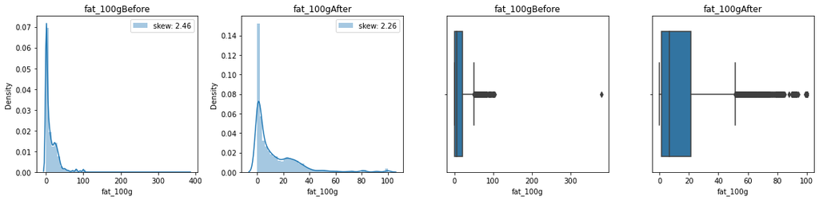

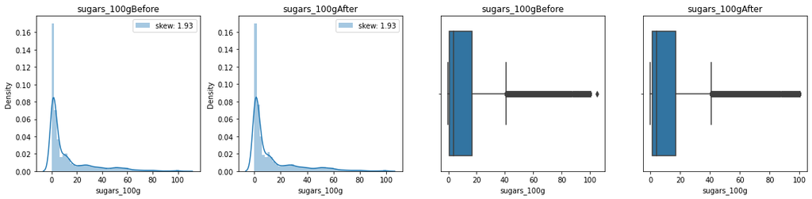

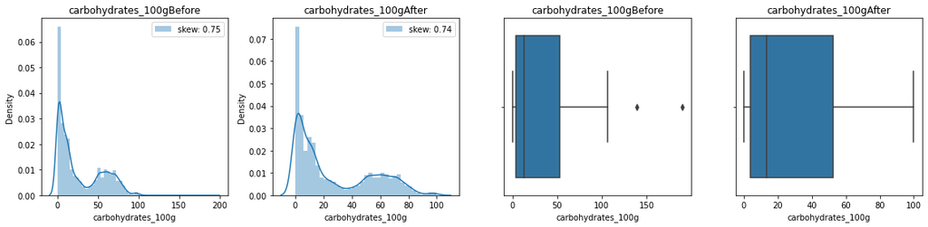

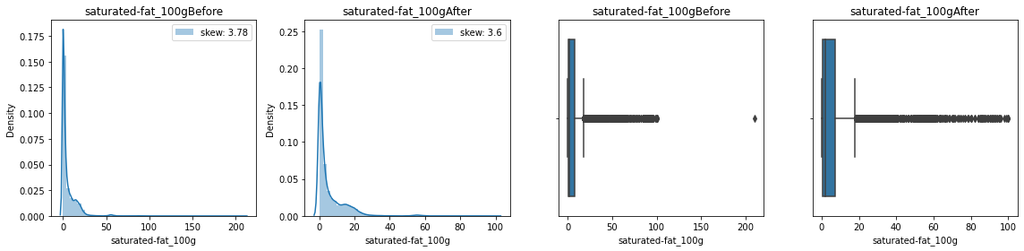

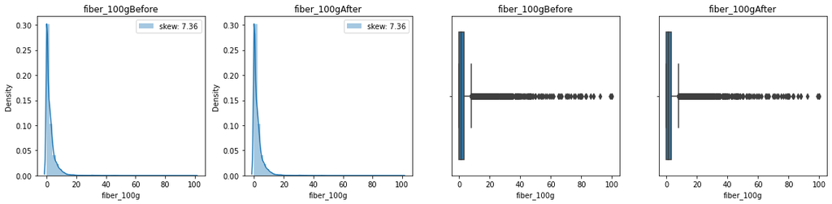

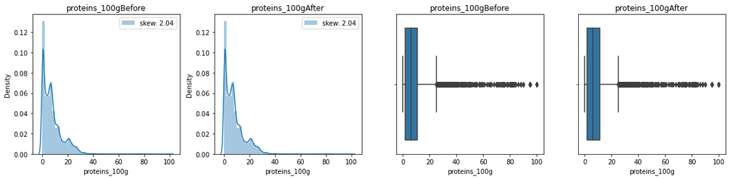

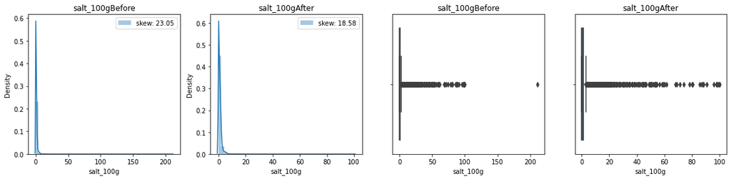

```python
for col in numerical_value_100g:
    plt.figure(figsize=(16, 4))

    plt.subplot(141)
    sns.distplot(df[col], label="skew: "+str(np.round(df[col].skew(),2)))
    plt.title(col + "Before")
    plt.legend()

    plt.subplot(142)
    sns.distplot(df_after[col], label="skew: "+str(np.round(df_after[col].skew(),2)))
    plt.title(col + "After")
    plt.legend()

    plt.subplot(143)
    sns.boxplot(df[col])
    plt.title(col + "Before")

    plt.subplot(144)
    sns.boxplot(df_after[col])
    plt.title(col + "After")
    plt.tight_layout()
    plt.show()
```

## Fat_100g

```python
df['fat_100g'].min()
```

```
0.0
```

```python
df['fat_100g'].max()
```

```
380.0
```

```python
df[df['fat_100g']>100]
```

|  | product_name | fat_100g | sugars_100g | energy_100g | carbohydrates_100g | saturated-fat_100g | fiber_100g | proteins_100g | salt_100g | nutrition-score-fr_100g | pnns_groups_1 | nutrition_grade_fr |
| --- | --- | --- | --- | --- | --- | --- | --- | --- | --- | --- | --- | --- |
| 245311 | mini choux goût fromage de chèvre - poivre | 380.0 | 22.7 | 18700.0 | 190.0 | 210.0 | 0.0 | 0.0 | 9.33 | 35.0 | Salty snacks | e |
| 305054 | Graine de couscous moyen | 105.0 | 2.5 | 1482.0 | 70.0 | 0.3 | NaN | 12.0 | 0.01 | -1.0 | Cereals and potatoes | a |

## saturated-fat_100g

```python
df['saturated-fat_100g'].min()
```

```
0.0
```

```python
df['saturated-fat_100g'].max()
```

```
210.0
```

```python
df[df['saturated-fat_100g']>100]
```

|  | product_name | fat_100g | sugars_100g | energy_100g | carbohydrates_100g | saturated-fat_100g | fiber_100g | proteins_100g | salt_100g | nutrition-score-fr_100g | pnns_groups_1 | nutrition_grade_fr |
| --- | --- | --- | --- | --- | --- | --- | --- | --- | --- | --- | --- | --- |
| 245311 | mini choux goût fromage de chèvre - poivre | 380.0 | 22.7 | 18700.0 | 190.0 | 210.0 | 0.0 | 0.0 | 9.33 | 35.0 | Salty snacks | e |

## sugars_100g

```python
df['sugars_100g'].min()
```

```
-0.1
```

```python
df['sugars_100g'].max()
```

```
105.0
```

```python
df[df['sugars_100g']<0]
```

|  | product_name | fat_100g | sugars_100g | energy_100g | carbohydrates_100g | saturated-fat_100g | fiber_100g | proteins_100g | salt_100g | nutrition-score-fr_100g | pnns_groups_1 | nutrition_grade_fr |
| --- | --- | --- | --- | --- | --- | --- | --- | --- | --- | --- | --- | --- |
| 195761 | Caprice des dieux | 30.0 | -0.1 | 1379.0 | 0.8 | 21.0 | NaN | 15.3 | 1.4 | 15.0 | Milk and dairy products | d |

```python
df[df['sugars_100g']>100]
```

|  | product_name | fat_100g | sugars_100g | energy_100g | carbohydrates_100g | saturated-fat_100g | fiber_100g | proteins_100g | salt_100g | nutrition-score-fr_100g | pnns_groups_1 | nutrition_grade_fr |
| --- | --- | --- | --- | --- | --- | --- | --- | --- | --- | --- | --- | --- |
| 239347 | Sirop d'agave | NaN | 105.0 | 1785.0 | 105.0 | NaN | NaN | NaN | NaN | NaN | Sugary snacks | NaN |

## carbohydrates_100g

```python
df['carbohydrates_100g'].min()
```

```
0.0
```

```python
df['carbohydrates_100g'].max()
```

```
190.0
```

```python
df[df['carbohydrates_100g']>100]
```

|  | product_name | fat_100g | sugars_100g | energy_100g | carbohydrates_100g | saturated-fat_100g | fiber_100g | proteins_100g | salt_100g | nutrition-score-fr_100g | pnns_groups_1 | nutrition_grade_fr |
| --- | --- | --- | --- | --- | --- | --- | --- | --- | --- | --- | --- | --- |
| 234726 | Palets pur beurre | 52.0 | 52.0 | 3925.0 | 106.0 | 35.5 | 3.0 | 10.0 | 1.30048 | 31.0 | Sugary snacks | e |
| 239347 | Sirop d'agave | NaN | 105.0 | 1785.0 | 105.0 | NaN | NaN | NaN | NaN | NaN | Sugary snacks | NaN |
| 245311 | mini choux goût fromage de chèvre - poivre | 380.0 | 22.7 | 18700.0 | 190.0 | 210.0 | 0.0 | 0.0 | 9.33000 | 35.0 | Salty snacks | e |
| 317635 | Banane sèche | 0.0 | 41.5 | 1259.0 | 139.0 | 0.0 | 0.0 | 5.0 | 0.00000 | 4.0 | Fruits and vegetables | c |

## fiber_100g

```python
df['fiber_100g'].min()
```

```
0.0
```

```python
df['fiber_100g'].max()
```

```
100.0
```

```python
df[df['fiber_100g']>100]
```

|  | product_name | fat_100g | sugars_100g | energy_100g | carbohydrates_100g | saturated-fat_100g | fiber_100g | proteins_100g | salt_100g | nutrition-score-fr_100g | pnns_groups_1 | nutrition_grade_fr |
| --- | --- | --- | --- | --- | --- | --- | --- | --- | --- | --- | --- | --- |

## proteins_100g

```python
df['proteins_100g'].min()
```

```
0.0
```

```python
df['proteins_100g'].max()
```

```
100.0
```

## salt_100g

```python
df['salt_100g'].min()
```

```
0.0
```

```python
df['salt_100g'].max()
```

```
211.0
```

```python
df[df['salt_100g']>100]
```

|  | product_name | fat_100g | sugars_100g | energy_100g | carbohydrates_100g | saturated-fat_100g | fiber_100g | proteins_100g | salt_100g | nutrition-score-fr_100g | pnns_groups_1 | nutrition_grade_fr |
| --- | --- | --- | --- | --- | --- | --- | --- | --- | --- | --- | --- | --- |
| 232239 | Keeny Bio | 23.0 | 26.7 | 1720.0 | 47.8 | 3.33 | 0.741 | 6.3 | 211.0 | 22.0 | Sugary snacks | e |

## Energy_100g

Quelle unitée de mesure Cal ou Joules

```python
df['energy_100g'].describe()
```

```
count    55446.000000
mean      1111.207844
std        802.255414
min          0.000000
25%        414.000000
50%       1025.000000
75%       1644.000000
max      18700.000000
Name: energy_100g, dtype: float64
```

```python
df[df['product_name']=='Cookies']
```

|  | product_name | fat_100g | sugars_100g | energy_100g | carbohydrates_100g | saturated-fat_100g | fiber_100g | proteins_100g | salt_100g | nutrition-score-fr_100g | pnns_groups_1 | nutrition_grade_fr |
| --- | --- | --- | --- | --- | --- | --- | --- | --- | --- | --- | --- | --- |
| 178084 | Cookies | 27.0 | 34.50 | 2132.0 | 58.0 | 12.00 | 3.5 | 7.0 | 1.2446 | 24.0 | Sugary snacks | e |
| 208629 | Cookies | 26.5 | 33.00 | 2118.0 | 58.5 | 12.50 | NaN | 6.5 | 1.2500 | 28.0 | Sugary snacks | e |
| 213357 | Cookies | NaN | 31.90 | 2142.0 | NaN | 13.20 | 2.9 | 5.9 | 1.3000 | 24.0 | Sugary snacks | e |
| 234713 | Cookies | NaN | 37.00 | 2138.0 | NaN | 27.70 | 0.0 | 5.9 | 0.6000 | 26.0 | NaN | e |
| 240765 | Cookies | 21.6 | 30.40 | 2061.0 | 65.8 | 10.40 | 3.4 | 6.8 | 0.6730 | 20.0 | Sugary snacks | e |
| 246351 | Cookies | NaN | 34.00 | 2029.0 | NaN | 12.00 | 5.0 | 7.0 | 0.4400 | 19.0 | Sugary snacks | e |
| 262391 | Cookies | NaN | 36.00 | 2008.0 | NaN | 7.30 | 6.3 | 3.5 | 0.7300 | 17.0 | NaN | d |
| 280200 | Cookies | NaN | 19.47 | 1966.0 | NaN | 18.65 | 0.0 | 4.9 | 0.2000 | 19.0 | NaN | e |
| 313435 | Cookies | 18.0 | 28.00 | 2020.0 | 74.0 | 8.50 | NaN | 5.5 | 0.9000 | 23.0 | Sugary snacks | e |

Selon USDA, Le cookie correspond à environ 502 calories soit environ 2100 Joules; Nous pouvons admettre qu'il semble que nos données soient en Joules

Parmi les aliments les plus caloriques, on retrouve les graisses d’origine animale Ce type de graisse se caractérise par une forte teneur en gras saturé, source de cholestérol, tout en étant dépourvu de nutriments intéressants. L’huile de poisson et le lard par exemple apportent près de 900 calories par 100 grammes soit 3800 J pour 100g

```python
df['energy_100g'].min()
```

```
0.0
```

```python
df['energy_100g'].max()
```

```
18700.0
```

```python
df[df['energy_100g']>3800]
```

|  | product_name | fat_100g | sugars_100g | energy_100g | carbohydrates_100g | saturated-fat_100g | fiber_100g | proteins_100g | salt_100g | nutrition-score-fr_100g | pnns_groups_1 | nutrition_grade_fr |
| --- | --- | --- | --- | --- | --- | --- | --- | --- | --- | --- | --- | --- |
| 56561 | Tawny' Orange | NaN | 65.00 | 5054.0 | NaN | 0.00 | 0.0 | 0.00 | 0.00000 | 20.0 | NaN | e |
| 161426 | Huile d'avocat | NaN | 0.00 | 3883.0 | NaN | 15.00 | 0.0 | 0.00 | 0.00000 | 20.0 | NaN | e |
| 178567 | Confiserie Firenze Apfel Streuselkuchen Tiefge... | NaN | 18.50 | 4197.0 | NaN | 3.90 | 0.0 | 2.90 | 0.11000 | 17.0 | NaN | d |
| 178787 | Halva with Almonds | 36.8 | 32.00 | 9983.0 | 44.2 | 7.80 | NaN | 12.90 | 0.00000 | 24.0 | Sugary snacks | e |
| 179179 | Lot De 4 Baguettes | NaN | 0.00 | 4184.0 | NaN | 0.00 | 0.0 | 0.00 | 0.00000 | 10.0 | NaN | c |
| 179586 | Tomatentapenade Bakje 150 Gram (baresa) Koeling | NaN | 13.00 | 4841.0 | NaN | 2.90 | 0.0 | 3.00 | 2.90000 | 24.0 | NaN | e |
| 181199 | Sauce beurre blanc et citron confit | NaN | 2.90 | 4607.0 | NaN | 17.00 | 2.0 | 0.50 | 1.20000 | 23.0 | NaN | e |
| 181503 | Lardons fumés | 20.0 | 0.70 | 4356.0 | 0.7 | 6.60 | NaN | 17.00 | 2.80000 | 26.0 | Fish Meat Eggs | e |
| 183135 | Diot de Savoie | NaN | 0.00 | 5050.0 | NaN | 9.70 | 0.0 | 18.00 | 22.00000 | 29.0 | NaN | e |
| 184458 | Pruneaux d'Agen Dénoyautés | 0.2 | 37.90 | 4117.0 | 52.3 | 0.10 | 0.0 | 2.40 | 0.01000 | 12.0 | Fruits and vegetables | d |
| 184758 | Pesto Rosso | NaN | 6.90 | 5268.0 | NaN | 4.20 | 0.0 | 4.10 | 2.50000 | 25.0 | NaN | e |
| 188751 | Rillettes De Poulet Roti | NaN | 0.10 | 5720.0 | NaN | 9.20 | 0.0 | 16.80 | 1.00000 | 23.0 | NaN | e |
| 188938 | Baguettines viennoises briochées | NaN | 1.00 | 5347.0 | NaN | 1.70 | 2.5 | 8.70 | 1.00000 | 12.0 | NaN | d |
| 190943 | Confiture Bonne Maman 370g | NaN | 59.00 | 4284.0 | NaN | 0.15 | 1.5 | 0.30 | 0.00000 | 18.0 | NaN | d |
| 192449 | Olives Cocktail Pimentées, Le Sachet De | NaN | 0.00 | 3908.0 | NaN | 3.26 | 6.7 | 1.20 | 2.50000 | 18.0 | NaN | d |
| 193248 | Sirop de cerise | NaN | 83.00 | 5904.0 | NaN | 0.00 | 0.0 | 0.00 | 0.00000 | 20.0 | Beverages | e |
| 193759 | Confiture de Châtaignes d'Ardèche | NaN | 41.00 | 4159.0 | NaN | 0.20 | 2.3 | 0.46 | 0.01000 | 15.0 | Sugary snacks | d |
| 199480 | Sirop Citron Bio au pur sucre de canne | NaN | 69.30 | 4929.0 | NaN | 0.10 | 0.0 | 0.10 | 0.10000 | 20.0 | NaN | e |
| 199505 | Sirop Saveur pina Colada | NaN | 79.00 | 5619.0 | NaN | 0.50 | 0.0 | 0.50 | 0.02000 | 20.0 | NaN | e |
| 199683 | Chevre Pane | NaN | 2.00 | 5205.0 | NaN | 12.00 | 0.0 | 14.00 | 1.30000 | 25.0 | NaN | e |
| 200423 | Confiture Extra, 4 Fruits Rouges, 370 Grammes,... | NaN | 60.00 | 4305.0 | NaN | 0.00 | 0.0 | 0.50 | 0.00000 | 20.0 | NaN | e |
| 202787 | 1KG Nuggets Poulet Maitre Coq | NaN | 1.30 | 4289.0 | NaN | 2.40 | 0.0 | 12.00 | 1.40000 | 18.0 | NaN | d |
| 203685 | Rillettes de sardine de Bretagne | NaN | 0.10 | 4000.0 | NaN | 4.60 | 0.0 | 14.00 | 1.10000 | 18.0 | Fish Meat Eggs | d |
| 204923 | Sirop Grenadine - Recette William | NaN | 73.50 | 5268.0 | NaN | 0.10 | 0.0 | 0.50 | 0.01000 | 20.0 | Beverages | e |
| 205801 | Tartelettes aux framboises sur crème pâtissièr... | NaN | 15.00 | 3904.0 | NaN | 5.90 | 0.0 | 2.70 | 0.10000 | 18.0 | NaN | d |
| 207590 | Pains Au Chocolat | NaN | 13.40 | 6109.0 | NaN | 19.00 | 0.0 | 7.30 | 0.90000 | 25.0 | Sugary snacks | e |
| 208054 | Panes Façon Cordon Bleu Vegetarien | NaN | 0.40 | 4217.0 | NaN | 2.90 | 5.2 | 13.90 | 1.60000 | 13.0 | NaN | d |
| 208805 | Sirop de citron pressor | NaN | 62.10 | 4418.0 | NaN | 0.00 | 0.0 | 0.00 | 0.00000 | 20.0 | NaN | e |
| 210322 | Purée Nature | 1.2 | 2.70 | 6138.0 | 28.9 | 0.80 | 9.7 | 5.20 | 0.10000 | NaN | Cereals and potatoes | NaN |
| 212719 | Mini-bonbons Sans Sucres, Menthe | NaN | 0.50 | 4058.0 | NaN | 0.00 | 0.0 | 0.00 | 0.02000 | 10.0 | Sugary snacks | c |

[output cut: 51 more lines]

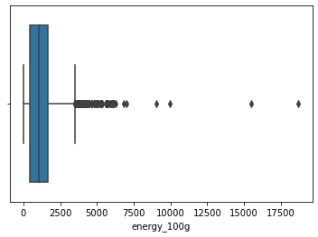

```python
sns.boxplot(df['energy_100g'])
```

```python
df.loc[df['energy_100g']>3800,'energy_100g'] = np.nan
```

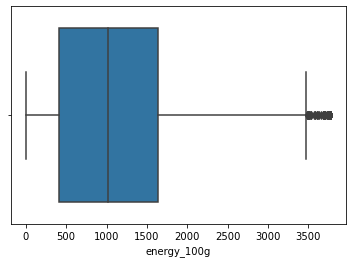

```python
sns.boxplot(df['energy_100g'])
```

# Valeurs atypiques :

Outliers par Pnns groupe, méthode interquartile (Tukey)

```python
import scipy.stats as stats
import plotly.express as px
```

```python
df = df_after
```

```python
Q1 = df.quantile(0.25)
Q3 = df.quantile(0.75)
IQR = Q3 - Q1
print(IQR)
```

```
fat_100g                     20.10
sugars_100g                  15.90
energy_100g                1230.00
carbohydrates_100g           48.90
saturated-fat_100g            7.10
fiber_100g                    3.10
proteins_100g                 9.31
salt_100g                     1.14
nutrition-score-fr_100g      14.00
dtype: float64
```

## Visualize using Box Plot

```python
pd.unique(df.pnns_groups_1.values)
```

```
array([nan, 'Cereals and potatoes', 'Sugary snacks', 'Beverages',
       'Fish Meat Eggs', 'Composite foods', 'Fruits and vegetables',
       'Milk and dairy products', 'Salty snacks', 'Fat and sauces'],
      dtype=object)
```

### fat_100g

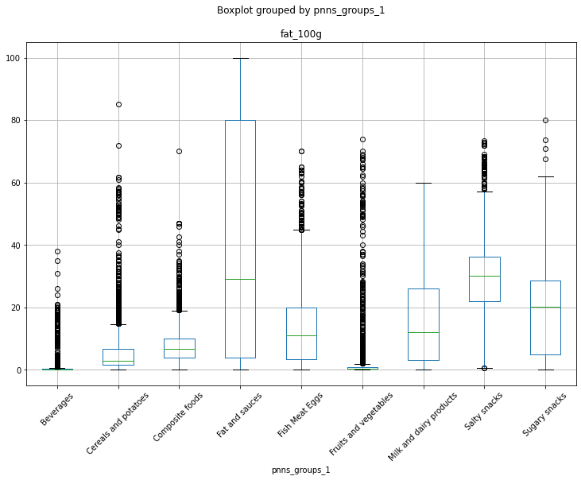

```python
#Create a boxplot
plt.figure(figsize=(15, 6))
df.boxplot('fat_100g', by='pnns_groups_1', figsize=(12, 8))
plt.xticks(rotation='45')
plt.show()
```

```python
q1 = df[df['pnns_groups_1'] == 'Beverages']['fat_100g'].quantile(.25)
q3 = df[df['pnns_groups_1'] == 'Beverages']['fat_100g'].quantile(.75)
IQR = q3 - q1
IQR
upper_boundary = q3 + (1.5 * IQR)
lower_boundary = q1 - (1.5 * IQR)
print("Upper Boundary using IQR  : {}".format(upper_boundary))
print("Lower Boundary using IQR  : {}".format(lower_boundary))

df_beverage = df[df['pnns_groups_1'] == 'Beverages']
df_beverage.loc[df_beverage['fat_100g'] > upper_boundary, 'fat_100g'] = np.nan

q1 = df[df['pnns_groups_1'] == 'Cereals and potatoes']['fat_100g'].quantile(.25)
q3 = df[df['pnns_groups_1'] == 'Cereals and potatoes']['fat_100g'].quantile(.75)
IQR = q3 - q1
IQR
upper_boundary = q3 + (1.5 * IQR)
lower_boundary = q1 - (1.5 * IQR)
print("Upper Boundary using IQR  : {}".format(upper_boundary))
print("Lower Boundary using IQR  : {}".format(lower_boundary))

df_cereals = df[df['pnns_groups_1'] == 'Cereals and potatoes']
df_cereals.loc[df_cereals['fat_100g'] > upper_boundary, 'fat_100g'] = np.nan

q1 = df[df['pnns_groups_1'] == 'Composite foods']['fat_100g'].quantile(.25)
q3 = df[df['pnns_groups_1'] == 'Composite foods']['fat_100g'].quantile(.75)
IQR = q3 - q1
IQR
upper_boundary = q3 + (1.5 * IQR)
lower_boundary = q1 - (1.5 * IQR)
print("Upper Boundary using IQR  : {}".format(upper_boundary))
print("Lower Boundary using IQR  : {}".format(lower_boundary))

df_composite = df[df['pnns_groups_1'] == 'Composite foods']
df_composite.loc[df_composite['fat_100g'] > upper_boundary, 'fat_100g'] = np.nan

q1 = df[df['pnns_groups_1'] == 'Fat and sauces']['fat_100g'].quantile(.25)
q3 = df[df['pnns_groups_1'] == 'Fat and sauces']['fat_100g'].quantile(.75)
IQR = q3 - q1
IQR
upper_boundary = q3 + (1.5 * IQR)
lower_boundary = q1 - (1.5 * IQR)
print("Upper Boundary using IQR  : {}".format(upper_boundary))
print("Lower Boundary using IQR  : {}".format(lower_boundary))
df_fat = df[df['pnns_groups_1'] == 'Fat and sauces']
df_fat.loc[df_fat['fat_100g'] > upper_boundary, 'fat_100g'] = np.nan

q1 = df[df['pnns_groups_1'] == 'Fish Meat Eggs']['fat_100g'].quantile(.25)
q3 = df[df['pnns_groups_1'] == 'Fish Meat Eggs']['fat_100g'].quantile(.75)
IQR = q3 - q1
IQR
upper_boundary = q3 + (1.5 * IQR)
lower_boundary = q1 - (1.5 * IQR)
print("Upper Boundary using IQR  : {}".format(upper_boundary))
print("Lower Boundary using IQR  : {}".format(lower_boundary))

df_fish = df[df['pnns_groups_1'] == 'Fish Meat Eggs']
df_fish.loc[df_fish['fat_100g'] > upper_boundary, 'fat_100g'] = np.nan

q1 = df[df['pnns_groups_1'] == 'Salty snacks']['fat_100g'].quantile(.25)
q3 = df[df['pnns_groups_1'] == 'Salty snacks']['fat_100g'].quantile(.75)
IQR = q3 - q1
IQR
upper_boundary = q3 + (1.5 * IQR)
lower_boundary = q1 - (1.5 * IQR)
print("Upper Boundary using IQR  : {}".format(upper_boundary))
print("Lower Boundary using IQR  : {}".format(lower_boundary))

df_salty = df[df['pnns_groups_1'] == 'Salty snacks']
df_salty.loc[df_salty['fat_100g'] > upper_boundary, 'fat_100g'] = np.nan

q1 = df[df['pnns_groups_1'] == 'Milk and dairy products']['fat_100g'].quantile(.25)
q3 = df[df['pnns_groups_1'] == 'Milk and dairy products']['fat_100g'].quantile(.75)
IQR = q3 - q1
IQR
upper_boundary = q3 + (1.5 * IQR)
lower_boundary = q1 - (1.5 * IQR)
print("Upper Boundary using IQR  : {}".format(upper_boundary))
print("Lower Boundary using IQR  : {}".format(lower_boundary))

df_milk = df[df['pnns_groups_1'] == 'Milk and dairy products']
df_milk.loc[df_milk['fat_100g'] > upper_boundary, 'fat_100g'] = np.nan

q1 = df[df['pnns_groups_1'] == 'Fruits and vegetables']['fat_100g'].quantile(.25)
q3 = df[df['pnns_groups_1'] == 'Fruits and vegetables']['fat_100g'].quantile(.75)
IQR = q3 - q1
IQR
upper_boundary = q3 + (1.5 * IQR)
lower_boundary = q1 - (1.5 * IQR)
print("Upper Boundary using IQR  : {}".format(upper_boundary))
print("Lower Boundary using IQR  : {}".format(lower_boundary))

df_fruits = df[df['pnns_groups_1'] == 'Fruits and vegetables']
df_fruits.loc[df_fruits['fat_100g'] > upper_boundary, 'fat_100g'] = np.nan

q1 = df[df['pnns_groups_1'] == 'Sugary snacks']['fat_100g'].quantile(.25)
q3 = df[df['pnns_groups_1'] == 'Sugary snacks']['fat_100g'].quantile(.75)
IQR = q3 - q1
IQR
upper_boundary = q3 + (1.5 * IQR)
lower_boundary = q1 - (1.5 * IQR)
print("Upper Boundary using IQR  : {}".format(upper_boundary))
print("Lower Boundary using IQR  : {}".format(lower_boundary))

df_sugary= df[df['pnns_groups_1'] == 'Sugary snacks']
df_sugary.loc[df_sugary['fat_100g'] > upper_boundary, 'fat_100g'] = np.nan
```

```
Upper Boundary using IQR  : 0.75
Lower Boundary using IQR  : -0.44999999999999996
Upper Boundary using IQR  : 14.75
Lower Boundary using IQR  : -6.449999999999999
Upper Boundary using IQR  : 19.0
Lower Boundary using IQR  : -5.0
Upper Boundary using IQR  : 194.14999999999998
Lower Boundary using IQR  : -110.24999999999999
Upper Boundary using IQR  : 44.900000000000006
Lower Boundary using IQR  : -21.500000000000004
Upper Boundary using IQR  : 57.625
Lower Boundary using IQR  : 0.625
Upper Boundary using IQR  : 60.349999999999994
Lower Boundary using IQR  : -31.249999999999993
Upper Boundary using IQR  : 1.9499999999999997
Lower Boundary using IQR  : -0.8499999999999999
Upper Boundary using IQR  : 63.875
Lower Boundary using IQR  : -30.325000000000003
```

```python
df = pd.concat([df_beverage, df_cereals, df_composite, df_fat,
               df_fish, df_salty, df_fruits, df_milk, df_sugary], axis=0)
```

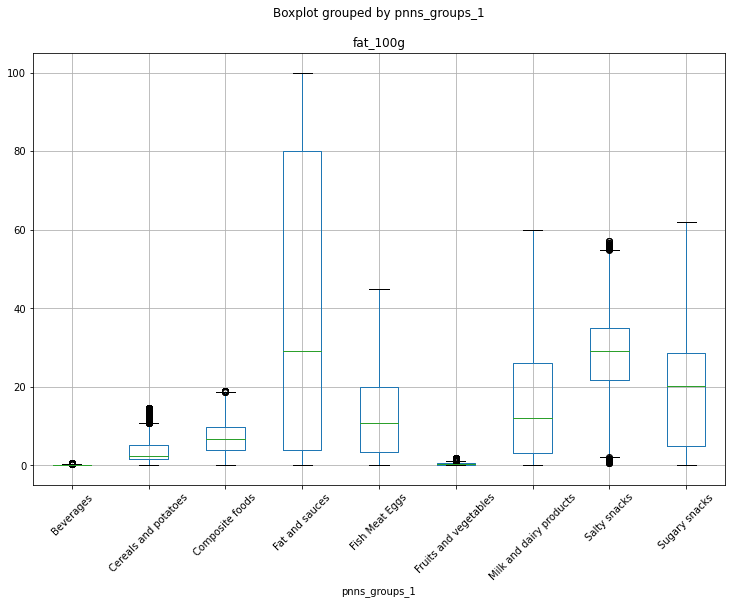

```python
#Create a boxplot
plt.figure(figsize=(15, 6))
df.boxplot('fat_100g', by='pnns_groups_1', figsize=(12, 8))
plt.xticks(rotation='45')
plt.show()
```

### sugars_100g

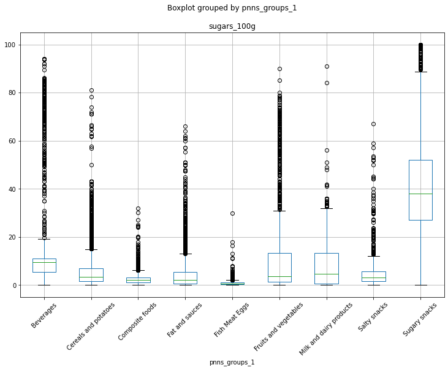

```python
#Create a boxplot
plt.figure(figsize=(15, 6))
df.boxplot('sugars_100g', by='pnns_groups_1', figsize=(12, 8))
plt.xticks(rotation='45')
plt.show()
```

```python
q1 = df[df['pnns_groups_1'] == 'Beverages']['sugars_100g'].quantile(.25)
q3 = df[df['pnns_groups_1'] == 'Beverages']['sugars_100g'].quantile(.75)
IQR = q3 - q1
IQR
upper_boundary = q3 + (1.5 * IQR)
lower_boundary = q1 - (1.5 * IQR)
print("Upper Boundary using IQR  : {}".format(upper_boundary))
print("Lower Boundary using IQR  : {}".format(lower_boundary))

df_beverage = df[df['pnns_groups_1'] == 'Beverages']
df_beverage.loc[df_beverage['sugars_100g'] > upper_boundary, 'sugars_100g'] = np.nan

q1 = df[df['pnns_groups_1'] == 'Cereals and potatoes']['sugars_100g'].quantile(.25)
q3 = df[df['pnns_groups_1'] == 'Cereals and potatoes']['sugars_100g'].quantile(.75)
IQR = q3 - q1
IQR
upper_boundary = q3 + (1.5 * IQR)
lower_boundary = q1 - (1.5 * IQR)
print("Upper Boundary using IQR  : {}".format(upper_boundary))
print("Lower Boundary using IQR  : {}".format(lower_boundary))

df_cereals = df[df['pnns_groups_1'] == 'Cereals and potatoes']
df_cereals.loc[df_cereals['sugars_100g'] > upper_boundary, 'sugars_100g'] = np.nan

q1 = df[df['pnns_groups_1'] == 'Composite foods']['sugars_100g'].quantile(.25)
q3 = df[df['pnns_groups_1'] == 'Composite foods']['sugars_100g'].quantile(.75)
IQR = q3 - q1
IQR
upper_boundary = q3 + (1.5 * IQR)
lower_boundary = q1 - (1.5 * IQR)
print("Upper Boundary using IQR  : {}".format(upper_boundary))
print("Lower Boundary using IQR  : {}".format(lower_boundary))

df_composite = df[df['pnns_groups_1'] == 'Composite foods']
df_composite.loc[df_composite['sugars_100g'] > upper_boundary, 'sugars_100g'] = np.nan

q1 = df[df['pnns_groups_1'] == 'Fat and sauces']['sugars_100g'].quantile(.25)
q3 = df[df['pnns_groups_1'] == 'Fat and sauces']['sugars_100g'].quantile(.75)
IQR = q3 - q1
IQR
upper_boundary = q3 + (1.5 * IQR)
lower_boundary = q1 - (1.5 * IQR)
print("Upper Boundary using IQR  : {}".format(upper_boundary))
print("Lower Boundary using IQR  : {}".format(lower_boundary))
df_fat = df[df['pnns_groups_1'] == 'Fat and sauces']
df_fat.loc[df_fat['sugars_100g'] > upper_boundary, 'sugars_100g'] = np.nan

q1 = df[df['pnns_groups_1'] == 'Fish Meat Eggs']['sugars_100g'].quantile(.25)
q3 = df[df['pnns_groups_1'] == 'Fish Meat Eggs']['sugars_100g'].quantile(.75)
IQR = q3 - q1
IQR
upper_boundary = q3 + (1.5 * IQR)
lower_boundary = q1 - (1.5 * IQR)
print("Upper Boundary using IQR  : {}".format(upper_boundary))
print("Lower Boundary using IQR  : {}".format(lower_boundary))

df_fish = df[df['pnns_groups_1'] == 'Fish Meat Eggs']
df_fish.loc[df_fish['sugars_100g'] > upper_boundary, 'sugars_100g'] = np.nan

q1 = df[df['pnns_groups_1'] == 'Salty snacks']['sugars_100g'].quantile(.25)
q3 = df[df['pnns_groups_1'] == 'Salty snacks']['sugars_100g'].quantile(.75)
IQR = q3 - q1
IQR
upper_boundary = q3 + (1.5 * IQR)
lower_boundary = q1 - (1.5 * IQR)
print("Upper Boundary using IQR  : {}".format(upper_boundary))
print("Lower Boundary using IQR  : {}".format(lower_boundary))

df_salty = df[df['pnns_groups_1'] == 'Salty snacks']
df_salty.loc[df_salty['sugars_100g'] > upper_boundary, 'sugars_100g'] = np.nan

q1 = df[df['pnns_groups_1'] == 'Milk and dairy products']['sugars_100g'].quantile(.25)
q3 = df[df['pnns_groups_1'] == 'Milk and dairy products']['sugars_100g'].quantile(.75)
IQR = q3 - q1
IQR
upper_boundary = q3 + (1.5 * IQR)
lower_boundary = q1 - (1.5 * IQR)
print("Upper Boundary using IQR  : {}".format(upper_boundary))
print("Lower Boundary using IQR  : {}".format(lower_boundary))

df_milk = df[df['pnns_groups_1'] == 'Milk and dairy products']
df_milk.loc[df_milk['sugars_100g'] > upper_boundary, 'sugars_100g'] = np.nan

q1 = df[df['pnns_groups_1'] == 'Fruits and vegetables']['sugars_100g'].quantile(.25)
q3 = df[df['pnns_groups_1'] == 'Fruits and vegetables']['sugars_100g'].quantile(.75)
IQR = q3 - q1
IQR
upper_boundary = q3 + (1.5 * IQR)
lower_boundary = q1 - (1.5 * IQR)
print("Upper Boundary using IQR  : {}".format(upper_boundary))
print("Lower Boundary using IQR  : {}".format(lower_boundary))

df_fruits = df[df['pnns_groups_1'] == 'Fruits and vegetables']
df_fruits.loc[df_fruits['sugars_100g'] > upper_boundary, 'sugars_100g'] = np.nan

q1 = df[df['pnns_groups_1'] == 'Sugary snacks']['sugars_100g'].quantile(.25)
q3 = df[df['pnns_groups_1'] == 'Sugary snacks']['sugars_100g'].quantile(.75)
IQR = q3 - q1
IQR
upper_boundary = q3 + (1.5 * IQR)
lower_boundary = q1 - (1.5 * IQR)
print("Upper Boundary using IQR  : {}".format(upper_boundary))
print("Lower Boundary using IQR  : {}".format(lower_boundary))

df_sugary= df[df['pnns_groups_1'] == 'Sugary snacks']
df_sugary.loc[df_sugary['sugars_100g'] > upper_boundary, 'sugars_100g'] = np.nan
```

```
Upper Boundary using IQR  : 19.55
Lower Boundary using IQR  : -3.250000000000001
Upper Boundary using IQR  : 14.955
Lower Boundary using IQR  : -6.5249999999999995
Upper Boundary using IQR  : 6.275
Lower Boundary using IQR  : -2.165
Upper Boundary using IQR  : 13.0
Lower Boundary using IQR  : -7.0
Upper Boundary using IQR  : 2.05
Lower Boundary using IQR  : -0.7499999999999998
Upper Boundary using IQR  : 12.0
Lower Boundary using IQR  : -4.800000000000001
Upper Boundary using IQR  : 32.25
Lower Boundary using IQR  : -18.549999999999997
Upper Boundary using IQR  : 31.049999999999997
Lower Boundary using IQR  : -16.549999999999997
Upper Boundary using IQR  : 89.5
Lower Boundary using IQR  : -10.5
```

```python
df = pd.concat([df_beverage, df_cereals, df_composite, df_fat,
               df_fish, df_salty, df_fruits, df_milk, df_sugary], axis=0)
```

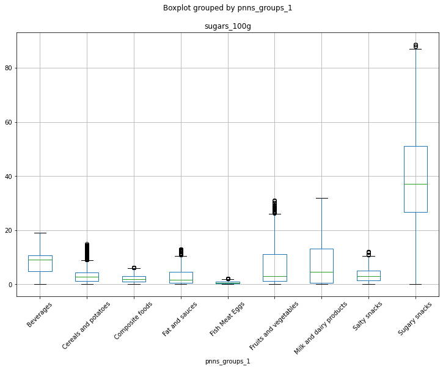

```python
#Create a boxplot
plt.figure(figsize=(15, 6))
df.boxplot('sugars_100g', by='pnns_groups_1', figsize=(12, 8))
plt.xticks(rotation='45')
plt.show()
```

### carbohydrates_100g

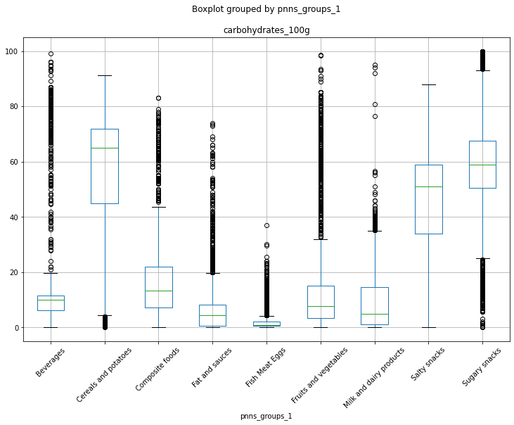

```python
#Create a boxplot
plt.figure(figsize=(15, 6))
df.boxplot('carbohydrates_100g', by='pnns_groups_1', figsize=(12, 8))
plt.xticks(rotation='45')
plt.show()
```

```python
q1 = df[df['pnns_groups_1'] == 'Beverages']['carbohydrates_100g'].quantile(.25)
q3 = df[df['pnns_groups_1'] == 'Beverages']['carbohydrates_100g'].quantile(.75)
IQR = q3 - q1
IQR
upper_boundary = q3 + (1.5 * IQR)
lower_boundary = q1 - (1.5 * IQR)
print("Upper Boundary using IQR  : {}".format(upper_boundary))
print("Lower Boundary using IQR  : {}".format(lower_boundary))

df_beverage = df[df['pnns_groups_1'] == 'Beverages']
df_beverage.loc[df_beverage['carbohydrates_100g'] > upper_boundary, 'carbohydrates_100g'] = np.nan

q1 = df[df['pnns_groups_1'] == 'Cereals and potatoes']['carbohydrates_100g'].quantile(.25)
q3 = df[df['pnns_groups_1'] == 'Cereals and potatoes']['carbohydrates_100g'].quantile(.75)
IQR = q3 - q1
IQR
upper_boundary = q3 + (1.5 * IQR)
lower_boundary = q1 - (1.5 * IQR)
print("Upper Boundary using IQR  : {}".format(upper_boundary))
print("Lower Boundary using IQR  : {}".format(lower_boundary))

df_cereals = df[df['pnns_groups_1'] == 'Cereals and potatoes']
df_cereals.loc[df_cereals['carbohydrates_100g'] > upper_boundary, 'carbohydrates_100g'] = np.nan
df_cereals.loc[df_cereals['carbohydrates_100g'] < lower_boundary, 'carbohydrates_100g'] = np.nan

q1 = df[df['pnns_groups_1'] == 'Composite foods']['carbohydrates_100g'].quantile(.25)
q3 = df[df['pnns_groups_1'] == 'Composite foods']['carbohydrates_100g'].quantile(.75)
IQR = q3 - q1
IQR
upper_boundary = q3 + (1.5 * IQR)
lower_boundary = q1 - (1.5 * IQR)
print("Upper Boundary using IQR  : {}".format(upper_boundary))
print("Lower Boundary using IQR  : {}".format(lower_boundary))

df_composite = df[df['pnns_groups_1'] == 'Composite foods']
df_composite.loc[df_composite['carbohydrates_100g'] > upper_boundary, 'carbohydrates_100g'] = np.nan

q1 = df[df['pnns_groups_1'] == 'Fat and sauces']['carbohydrates_100g'].quantile(.25)
q3 = df[df['pnns_groups_1'] == 'Fat and sauces']['carbohydrates_100g'].quantile(.75)
IQR = q3 - q1
IQR
upper_boundary = q3 + (1.5 * IQR)
lower_boundary = q1 - (1.5 * IQR)
print("Upper Boundary using IQR  : {}".format(upper_boundary))
print("Lower Boundary using IQR  : {}".format(lower_boundary))
df_fat = df[df['pnns_groups_1'] == 'Fat and sauces']
df_fat.loc[df_fat['carbohydrates_100g'] > upper_boundary, 'carbohydrates_100g'] = np.nan

q1 = df[df['pnns_groups_1'] == 'Fish Meat Eggs']['carbohydrates_100g'].quantile(.25)
q3 = df[df['pnns_groups_1'] == 'Fish Meat Eggs']['carbohydrates_100g'].quantile(.75)
IQR = q3 - q1
IQR
upper_boundary = q3 + (1.5 * IQR)
lower_boundary = q1 - (1.5 * IQR)
print("Upper Boundary using IQR  : {}".format(upper_boundary))
print("Lower Boundary using IQR  : {}".format(lower_boundary))

df_fish = df[df['pnns_groups_1'] == 'Fish Meat Eggs']
df_fish.loc[df_fish['carbohydrates_100g'] > upper_boundary, 'carbohydrates_100g'] = np.nan

q1 = df[df['pnns_groups_1'] == 'Salty snacks']['carbohydrates_100g'].quantile(.25)
q3 = df[df['pnns_groups_1'] == 'Salty snacks']['carbohydrates_100g'].quantile(.75)
IQR = q3 - q1
IQR
upper_boundary = q3 + (1.5 * IQR)
lower_boundary = q1 - (1.5 * IQR)
print("Upper Boundary using IQR  : {}".format(upper_boundary))
print("Lower Boundary using IQR  : {}".format(lower_boundary))

df_salty = df[df['pnns_groups_1'] == 'Salty snacks']
df_salty.loc[df_salty['carbohydrates_100g'] > upper_boundary, 'carbohydrates_100g'] = np.nan

q1 = df[df['pnns_groups_1'] == 'Milk and dairy products']['carbohydrates_100g'].quantile(.25)
q3 = df[df['pnns_groups_1'] == 'Milk and dairy products']['carbohydrates_100g'].quantile(.75)
IQR = q3 - q1
IQR
upper_boundary = q3 + (1.5 * IQR)
lower_boundary = q1 - (1.5 * IQR)
print("Upper Boundary using IQR  : {}".format(upper_boundary))
print("Lower Boundary using IQR  : {}".format(lower_boundary))

df_milk = df[df['pnns_groups_1'] == 'Milk and dairy products']
df_milk.loc[df_milk['carbohydrates_100g'] > upper_boundary, 'carbohydrates_100g'] = np.nan

q1 = df[df['pnns_groups_1'] == 'Fruits and vegetables']['carbohydrates_100g'].quantile(.25)
q3 = df[df['pnns_groups_1'] == 'Fruits and vegetables']['carbohydrates_100g'].quantile(.75)
IQR = q3 - q1
IQR
upper_boundary = q3 + (1.5 * IQR)
lower_boundary = q1 - (1.5 * IQR)
print("Upper Boundary using IQR  : {}".format(upper_boundary))
print("Lower Boundary using IQR  : {}".format(lower_boundary))

df_fruits = df[df['pnns_groups_1'] == 'Fruits and vegetables']
df_fruits.loc[df_fruits['carbohydrates_100g'] > upper_boundary, 'carbohydrates_100g'] = np.nan

q1 = df[df['pnns_groups_1'] == 'Sugary snacks']['carbohydrates_100g'].quantile(.25)
q3 = df[df['pnns_groups_1'] == 'Sugary snacks']['carbohydrates_100g'].quantile(.75)
IQR = q3 - q1
IQR
upper_boundary = q3 + (1.5 * IQR)
lower_boundary = q1 - (1.5 * IQR)
print("Upper Boundary using IQR  : {}".format(upper_boundary))
print("Lower Boundary using IQR  : {}".format(lower_boundary))

df_sugary= df[df['pnns_groups_1'] == 'Sugary snacks']
df_sugary.loc[df_sugary['carbohydrates_100g'] > upper_boundary, 'carbohydrates_100g'] = np.nan
df_sugary.loc[df_sugary['carbohydrates_100g'] < lower_boundary, 'carbohydrates_100g'] = np.nan
```

```
Upper Boundary using IQR  : 19.85
Lower Boundary using IQR  : -2.1500000000000004
Upper Boundary using IQR  : 112.65
Lower Boundary using IQR  : 4.249999999999993
Upper Boundary using IQR  : 44.2
Lower Boundary using IQR  : -15.000000000000004
Upper Boundary using IQR  : 19.85
Lower Boundary using IQR  : -10.950000000000001
Upper Boundary using IQR  : 4.25
Lower Boundary using IQR  : -1.75
Upper Boundary using IQR  : 96.5
Lower Boundary using IQR  : -3.5
Upper Boundary using IQR  : 35.0
Lower Boundary using IQR  : -19.4
Upper Boundary using IQR  : 32.4
Lower Boundary using IQR  : -13.999999999999998
Upper Boundary using IQR  : 93.24999999999999
Lower Boundary using IQR  : 24.85000000000001
```

```python
df = pd.concat([df_beverage, df_cereals, df_composite, df_fat,
               df_fish, df_salty, df_fruits, df_milk, df_sugary], axis=0)
```

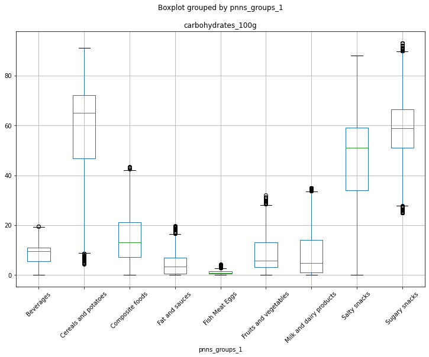

```python
#Create a boxplot
plt.figure(figsize=(15, 6))
df.boxplot('carbohydrates_100g', by='pnns_groups_1', figsize=(12, 8))
plt.xticks(rotation='45')
plt.show()
```

### saturated-fat_100g

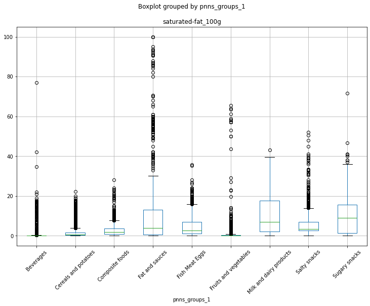

```python
#Create a boxplot
plt.figure(figsize=(15, 6))
df.boxplot('saturated-fat_100g', by='pnns_groups_1', figsize=(12, 8))
plt.xticks(rotation='45')
plt.show()
```

```python
q1 = df[df['pnns_groups_1'] == 'Beverages']['saturated-fat_100g'].quantile(.25)
q3 = df[df['pnns_groups_1'] == 'Beverages']['saturated-fat_100g'].quantile(.75)
IQR = q3 - q1
IQR
upper_boundary = q3 + (1.5 * IQR)
lower_boundary = q1 - (1.5 * IQR)
print("Upper Boundary using IQR  : {}".format(upper_boundary))
print("Lower Boundary using IQR  : {}".format(lower_boundary))

df_beverage = df[df['pnns_groups_1'] == 'Beverages']
df_beverage.loc[df_beverage['saturated-fat_100g'] > upper_boundary, 'saturated-fat_100g'] = np.nan

q1 = df[df['pnns_groups_1'] == 'Cereals and potatoes']['saturated-fat_100g'].quantile(.25)
q3 = df[df['pnns_groups_1'] == 'Cereals and potatoes']['saturated-fat_100g'].quantile(.75)
IQR = q3 - q1
IQR
upper_boundary = q3 + (1.5 * IQR)
lower_boundary = q1 - (1.5 * IQR)
print("Upper Boundary using IQR  : {}".format(upper_boundary))
print("Lower Boundary using IQR  : {}".format(lower_boundary))

df_cereals = df[df['pnns_groups_1'] == 'Cereals and potatoes']
df_cereals.loc[df_cereals['saturated-fat_100g'] > upper_boundary, 'saturated-fat_100g'] = np.nan
df_cereals.loc[df_cereals['saturated-fat_100g'] < lower_boundary, 'saturated-fat_100g'] = np.nan

q1 = df[df['pnns_groups_1'] == 'Composite foods']['saturated-fat_100g'].quantile(.25)
q3 = df[df['pnns_groups_1'] == 'Composite foods']['saturated-fat_100g'].quantile(.75)
IQR = q3 - q1
IQR
upper_boundary = q3 + (1.5 * IQR)
lower_boundary = q1 - (1.5 * IQR)
print("Upper Boundary using IQR  : {}".format(upper_boundary))
print("Lower Boundary using IQR  : {}".format(lower_boundary))

df_composite = df[df['pnns_groups_1'] == 'Composite foods']
df_composite.loc[df_composite['saturated-fat_100g'] > upper_boundary, 'saturated-fat_100g'] = np.nan

q1 = df[df['pnns_groups_1'] == 'Fat and sauces']['saturated-fat_100g'].quantile(.25)
q3 = df[df['pnns_groups_1'] == 'Fat and sauces']['saturated-fat_100g'].quantile(.75)
IQR = q3 - q1
IQR
upper_boundary = q3 + (1.5 * IQR)
lower_boundary = q1 - (1.5 * IQR)
print("Upper Boundary using IQR  : {}".format(upper_boundary))
print("Lower Boundary using IQR  : {}".format(lower_boundary))
df_fat = df[df['pnns_groups_1'] == 'Fat and sauces']
df_fat.loc[df_fat['saturated-fat_100g'] > upper_boundary, 'saturated-fat_100g'] = np.nan

q1 = df[df['pnns_groups_1'] == 'Fish Meat Eggs']['saturated-fat_100g'].quantile(.25)
q3 = df[df['pnns_groups_1'] == 'Fish Meat Eggs']['saturated-fat_100g'].quantile(.75)
IQR = q3 - q1
IQR
upper_boundary = q3 + (1.5 * IQR)
lower_boundary = q1 - (1.5 * IQR)
print("Upper Boundary using IQR  : {}".format(upper_boundary))
print("Lower Boundary using IQR  : {}".format(lower_boundary))

df_fish = df[df['pnns_groups_1'] == 'Fish Meat Eggs']
df_fish.loc[df_fish['saturated-fat_100g'] > upper_boundary, 'saturated-fat_100g'] = np.nan

q1 = df[df['pnns_groups_1'] == 'Salty snacks']['saturated-fat_100g'].quantile(.25)
q3 = df[df['pnns_groups_1'] == 'Salty snacks']['saturated-fat_100g'].quantile(.75)
IQR = q3 - q1
IQR
upper_boundary = q3 + (1.5 * IQR)
lower_boundary = q1 - (1.5 * IQR)
print("Upper Boundary using IQR  : {}".format(upper_boundary))
print("Lower Boundary using IQR  : {}".format(lower_boundary))

df_salty = df[df['pnns_groups_1'] == 'Salty snacks']
df_salty.loc[df_salty['saturated-fat_100g'] > upper_boundary, 'saturated-fat_100g'] = np.nan

q1 = df[df['pnns_groups_1'] == 'Milk and dairy products']['saturated-fat_100g'].quantile(.25)
q3 = df[df['pnns_groups_1'] == 'Milk and dairy products']['saturated-fat_100g'].quantile(.75)
IQR = q3 - q1
IQR
upper_boundary = q3 + (1.5 * IQR)
lower_boundary = q1 - (1.5 * IQR)
print("Upper Boundary using IQR  : {}".format(upper_boundary))
print("Lower Boundary using IQR  : {}".format(lower_boundary))

df_milk = df[df['pnns_groups_1'] == 'Milk and dairy products']
df_milk.loc[df_milk['saturated-fat_100g'] > upper_boundary, 'saturated-fat_100g'] = np.nan

q1 = df[df['pnns_groups_1'] == 'Fruits and vegetables']['saturated-fat_100g'].quantile(.25)
q3 = df[df['pnns_groups_1'] == 'Fruits and vegetables']['saturated-fat_100g'].quantile(.75)
IQR = q3 - q1
IQR
upper_boundary = q3 + (1.5 * IQR)
lower_boundary = q1 - (1.5 * IQR)
print("Upper Boundary using IQR  : {}".format(upper_boundary))
print("Lower Boundary using IQR  : {}".format(lower_boundary))

df_fruits = df[df['pnns_groups_1'] == 'Fruits and vegetables']
df_fruits.loc[df_fruits['saturated-fat_100g'] > upper_boundary, 'saturated-fat_100g'] = np.nan

q1 = df[df['pnns_groups_1'] == 'Sugary snacks']['saturated-fat_100g'].quantile(.25)
q3 = df[df['pnns_groups_1'] == 'Sugary snacks']['saturated-fat_100g'].quantile(.75)
IQR = q3 - q1
IQR
upper_boundary = q3 + (1.5 * IQR)
lower_boundary = q1 - (1.5 * IQR)
print("Upper Boundary using IQR  : {}".format(upper_boundary))
print("Lower Boundary using IQR  : {}".format(lower_boundary))

df_sugary= df[df['pnns_groups_1'] == 'Sugary snacks']
df_sugary.loc[df_sugary['saturated-fat_100g'] > upper_boundary, 'saturated-fat_100g'] = np.nan
df_sugary.loc[df_sugary['saturated-fat_100g'] < lower_boundary, 'saturated-fat_100g'] = np.nan
```

```
Upper Boundary using IQR  : 0.25
Lower Boundary using IQR  : -0.15000000000000002
Upper Boundary using IQR  : 3.8
Lower Boundary using IQR  : -1.7999999999999996
Upper Boundary using IQR  : 7.799999999999999
Lower Boundary using IQR  : -3.3999999999999995
Upper Boundary using IQR  : 31.6
Lower Boundary using IQR  : -18.0
Upper Boundary using IQR  : 15.850000000000001
Lower Boundary using IQR  : -7.750000000000002
Upper Boundary using IQR  : 13.75
Lower Boundary using IQR  : -4.25
Upper Boundary using IQR  : 41.25
Lower Boundary using IQR  : -21.549999999999997
Upper Boundary using IQR  : 0.75
Lower Boundary using IQR  : -0.44999999999999996
Upper Boundary using IQR  : 36.9
Lower Boundary using IQR  : -19.9
```

```python
df = pd.concat([df_beverage, df_cereals, df_composite, df_fat,
               df_fish, df_salty, df_fruits, df_milk, df_sugary], axis=0)
```

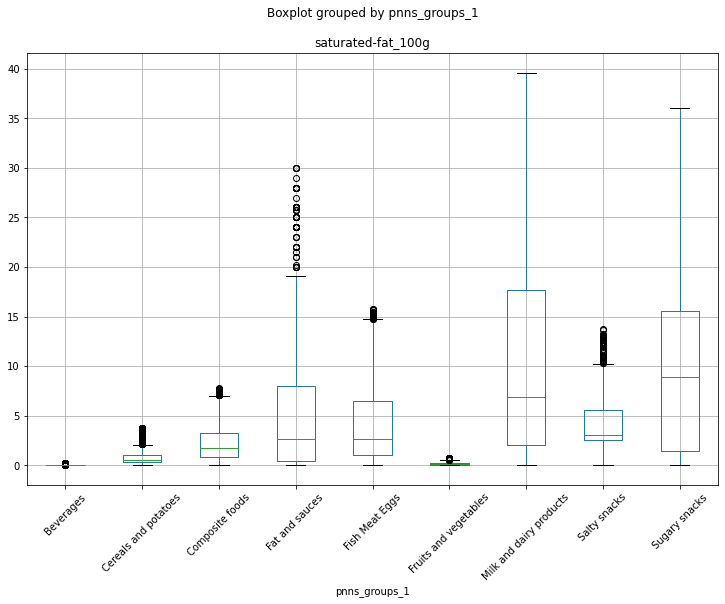

```python
#Create a boxplot
plt.figure(figsize=(15, 6))
df.boxplot('saturated-fat_100g', by='pnns_groups_1', figsize=(12, 8))
plt.xticks(rotation='45')
plt.show()
```

### fiber_100g

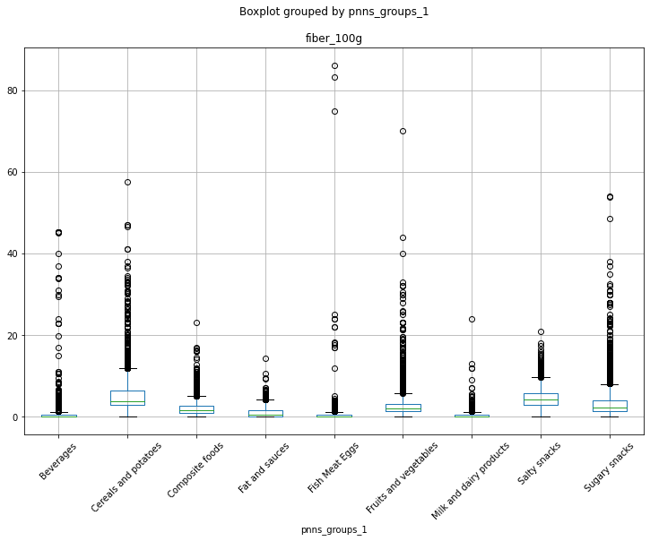

```python
#Create a boxplot
plt.figure(figsize=(15, 6))
df.boxplot('fiber_100g', by='pnns_groups_1', figsize=(12, 8))
plt.xticks(rotation='45')
plt.show()
```

```python
q1 = df[df['pnns_groups_1'] == 'Beverages']['fiber_100g'].quantile(.25)
q3 = df[df['pnns_groups_1'] == 'Beverages']['fiber_100g'].quantile(.75)
IQR = q3 - q1
IQR
upper_boundary = q3 + (1.5 * IQR)
lower_boundary = q1 - (1.5 * IQR)
print("Upper Boundary using IQR  : {}".format(upper_boundary))
print("Lower Boundary using IQR  : {}".format(lower_boundary))

df_beverage = df[df['pnns_groups_1'] == 'Beverages']
df_beverage.loc[df_beverage['fiber_100g'] > upper_boundary, 'fiber_100g'] = np.nan

q1 = df[df['pnns_groups_1'] == 'Cereals and potatoes']['fiber_100g'].quantile(.25)
q3 = df[df['pnns_groups_1'] == 'Cereals and potatoes']['fiber_100g'].quantile(.75)
IQR = q3 - q1
IQR
upper_boundary = q3 + (1.5 * IQR)
lower_boundary = q1 - (1.5 * IQR)
print("Upper Boundary using IQR  : {}".format(upper_boundary))
print("Lower Boundary using IQR  : {}".format(lower_boundary))

df_cereals = df[df['pnns_groups_1'] == 'Cereals and potatoes']
df_cereals.loc[df_cereals['fiber_100g'] > upper_boundary, 'fiber_100g'] = np.nan
df_cereals.loc[df_cereals['fiber_100g'] < lower_boundary, 'fiber_100g'] = np.nan

q1 = df[df['pnns_groups_1'] == 'Composite foods']['fiber_100g'].quantile(.25)
q3 = df[df['pnns_groups_1'] == 'Composite foods']['fiber_100g'].quantile(.75)
IQR = q3 - q1
IQR
upper_boundary = q3 + (1.5 * IQR)
lower_boundary = q1 - (1.5 * IQR)
print("Upper Boundary using IQR  : {}".format(upper_boundary))
print("Lower Boundary using IQR  : {}".format(lower_boundary))

df_composite = df[df['pnns_groups_1'] == 'Composite foods']
df_composite.loc[df_composite['fiber_100g'] > upper_boundary, 'fiber_100g'] = np.nan

q1 = df[df['pnns_groups_1'] == 'Fat and sauces']['fiber_100g'].quantile(.25)
q3 = df[df['pnns_groups_1'] == 'Fat and sauces']['fiber_100g'].quantile(.75)
IQR = q3 - q1
IQR
upper_boundary = q3 + (1.5 * IQR)
lower_boundary = q1 - (1.5 * IQR)
print("Upper Boundary using IQR  : {}".format(upper_boundary))
print("Lower Boundary using IQR  : {}".format(lower_boundary))
df_fat = df[df['pnns_groups_1'] == 'Fat and sauces']
df_fat.loc[df_fat['fiber_100g'] > upper_boundary, 'fiber_100g'] = np.nan

q1 = df[df['pnns_groups_1'] == 'Fish Meat Eggs']['fiber_100g'].quantile(.25)
q3 = df[df['pnns_groups_1'] == 'Fish Meat Eggs']['fiber_100g'].quantile(.75)
IQR = q3 - q1
IQR
upper_boundary = q3 + (1.5 * IQR)
lower_boundary = q1 - (1.5 * IQR)
print("Upper Boundary using IQR  : {}".format(upper_boundary))
print("Lower Boundary using IQR  : {}".format(lower_boundary))

df_fish = df[df['pnns_groups_1'] == 'Fish Meat Eggs']
df_fish.loc[df_fish['fiber_100g'] > upper_boundary, 'fiber_100g'] = np.nan

q1 = df[df['pnns_groups_1'] == 'Salty snacks']['fiber_100g'].quantile(.25)
q3 = df[df['pnns_groups_1'] == 'Salty snacks']['fiber_100g'].quantile(.75)
IQR = q3 - q1
IQR
upper_boundary = q3 + (1.5 * IQR)
lower_boundary = q1 - (1.5 * IQR)
print("Upper Boundary using IQR  : {}".format(upper_boundary))
print("Lower Boundary using IQR  : {}".format(lower_boundary))

df_salty = df[df['pnns_groups_1'] == 'Salty snacks']
df_salty.loc[df_salty['fiber_100g'] > upper_boundary, 'fiber_100g'] = np.nan

q1 = df[df['pnns_groups_1'] == 'Milk and dairy products']['fiber_100g'].quantile(.25)
q3 = df[df['pnns_groups_1'] == 'Milk and dairy products']['fiber_100g'].quantile(.75)
IQR = q3 - q1
IQR
upper_boundary = q3 + (1.5 * IQR)
lower_boundary = q1 - (1.5 * IQR)
print("Upper Boundary using IQR  : {}".format(upper_boundary))
print("Lower Boundary using IQR  : {}".format(lower_boundary))

df_milk = df[df['pnns_groups_1'] == 'Milk and dairy products']
df_milk.loc[df_milk['fiber_100g'] > upper_boundary, 'fiber_100g'] = np.nan

q1 = df[df['pnns_groups_1'] == 'Fruits and vegetables']['fiber_100g'].quantile(.25)
q3 = df[df['pnns_groups_1'] == 'Fruits and vegetables']['fiber_100g'].quantile(.75)
IQR = q3 - q1
IQR
upper_boundary = q3 + (1.5 * IQR)
lower_boundary = q1 - (1.5 * IQR)
print("Upper Boundary using IQR  : {}".format(upper_boundary))
print("Lower Boundary using IQR  : {}".format(lower_boundary))

df_fruits = df[df['pnns_groups_1'] == 'Fruits and vegetables']
df_fruits.loc[df_fruits['fiber_100g'] > upper_boundary, 'fiber_100g'] = np.nan

q1 = df[df['pnns_groups_1'] == 'Sugary snacks']['fiber_100g'].quantile(.25)
q3 = df[df['pnns_groups_1'] == 'Sugary snacks']['fiber_100g'].quantile(.75)
IQR = q3 - q1
IQR
upper_boundary = q3 + (1.5 * IQR)
lower_boundary = q1 - (1.5 * IQR)
print("Upper Boundary using IQR  : {}".format(upper_boundary))
print("Lower Boundary using IQR  : {}".format(lower_boundary))

df_sugary= df[df['pnns_groups_1'] == 'Sugary snacks']
df_sugary.loc[df_sugary['fiber_100g'] > upper_boundary, 'fiber_100g'] = np.nan
df_sugary.loc[df_sugary['fiber_100g'] < lower_boundary, 'fiber_100g'] = np.nan
```

```
Upper Boundary using IQR  : 1.25
Lower Boundary using IQR  : -0.75
Upper Boundary using IQR  : 11.9
Lower Boundary using IQR  : -2.5000000000000004
Upper Boundary using IQR  : 5.0
Lower Boundary using IQR  : -1.4000000000000004
Upper Boundary using IQR  : 4.25
Lower Boundary using IQR  : -2.55
Upper Boundary using IQR  : 1.25
Lower Boundary using IQR  : -0.75
Upper Boundary using IQR  : 9.75
Lower Boundary using IQR  : -1.0500000000000007
Upper Boundary using IQR  : 1.25
Lower Boundary using IQR  : -0.75
Upper Boundary using IQR  : 5.800000000000001
Lower Boundary using IQR  : -1.4000000000000001
Upper Boundary using IQR  : 8.05
Lower Boundary using IQR  : -2.750000000000001
```

```python
df = pd.concat([df_beverage, df_cereals, df_composite, df_fat,
               df_fish, df_salty, df_fruits, df_milk, df_sugary], axis=0)
```

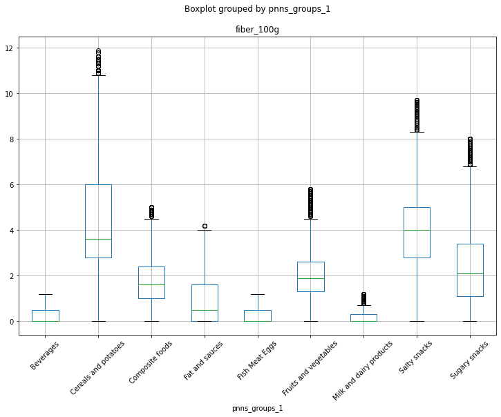

```python
#Create a boxplot
plt.figure(figsize=(15, 6))
df.boxplot('fiber_100g', by='pnns_groups_1', figsize=(12, 8))
plt.xticks(rotation='45')
plt.show()
```

### proteins_100g

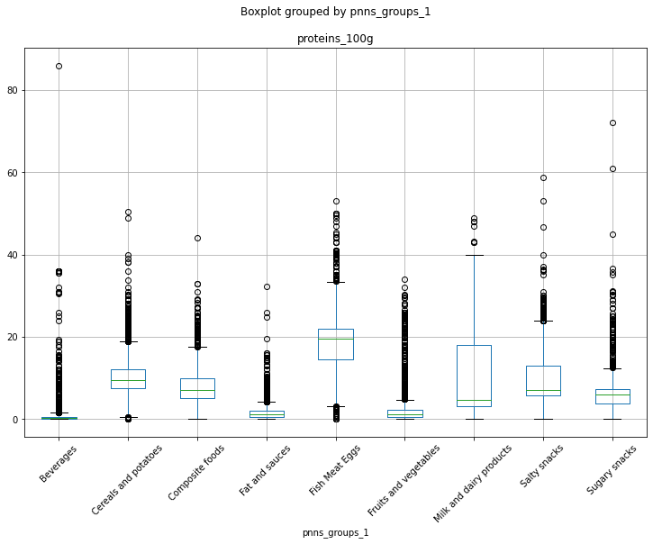

```python
#Create a boxplot
plt.figure(figsize=(15, 6))
df.boxplot('proteins_100g', by='pnns_groups_1', figsize=(12, 8))
plt.xticks(rotation='45')
plt.show()
```

```python
q1 = df[df['pnns_groups_1'] == 'Beverages']['proteins_100g'].quantile(.25)
q3 = df[df['pnns_groups_1'] == 'Beverages']['proteins_100g'].quantile(.75)
IQR = q3 - q1
IQR
upper_boundary = q3 + (1.5 * IQR)
lower_boundary = q1 - (1.5 * IQR)
print("Upper Boundary using IQR  : {}".format(upper_boundary))
print("Lower Boundary using IQR  : {}".format(lower_boundary))

df_beverage = df[df['pnns_groups_1'] == 'Beverages']
df_beverage.loc[df_beverage['proteins_100g'] > upper_boundary, 'proteins_100g'] = np.nan

q1 = df[df['pnns_groups_1'] == 'Cereals and potatoes']['proteins_100g'].quantile(.25)
q3 = df[df['pnns_groups_1'] == 'Cereals and potatoes']['proteins_100g'].quantile(.75)
IQR = q3 - q1
IQR
upper_boundary = q3 + (1.5 * IQR)
lower_boundary = q1 - (1.5 * IQR)
print("Upper Boundary using IQR  : {}".format(upper_boundary))
print("Lower Boundary using IQR  : {}".format(lower_boundary))

df_cereals = df[df['pnns_groups_1'] == 'Cereals and potatoes']
df_cereals.loc[df_cereals['proteins_100g'] > upper_boundary, 'proteins_100g'] = np.nan
df_cereals.loc[df_cereals['proteins_100g'] < lower_boundary, 'proteins_100g'] = np.nan

q1 = df[df['pnns_groups_1'] == 'Composite foods']['proteins_100g'].quantile(.25)
q3 = df[df['pnns_groups_1'] == 'Composite foods']['proteins_100g'].quantile(.75)
IQR = q3 - q1
IQR
upper_boundary = q3 + (1.5 * IQR)
lower_boundary = q1 - (1.5 * IQR)
print("Upper Boundary using IQR  : {}".format(upper_boundary))
print("Lower Boundary using IQR  : {}".format(lower_boundary))

df_composite = df[df['pnns_groups_1'] == 'Composite foods']
df_composite.loc[df_composite['proteins_100g'] > upper_boundary, 'proteins_100g'] = np.nan

q1 = df[df['pnns_groups_1'] == 'Fat and sauces']['proteins_100g'].quantile(.25)
q3 = df[df['pnns_groups_1'] == 'Fat and sauces']['proteins_100g'].quantile(.75)
IQR = q3 - q1
IQR
upper_boundary = q3 + (1.5 * IQR)
lower_boundary = q1 - (1.5 * IQR)
print("Upper Boundary using IQR  : {}".format(upper_boundary))
print("Lower Boundary using IQR  : {}".format(lower_boundary))
df_fat = df[df['pnns_groups_1'] == 'Fat and sauces']
df_fat.loc[df_fat['proteins_100g'] > upper_boundary, 'proteins_100g'] = np.nan

q1 = df[df['pnns_groups_1'] == 'Fish Meat Eggs']['proteins_100g'].quantile(.25)
q3 = df[df['pnns_groups_1'] == 'Fish Meat Eggs']['proteins_100g'].quantile(.75)
IQR = q3 - q1
IQR
upper_boundary = q3 + (1.5 * IQR)
lower_boundary = q1 - (1.5 * IQR)
print("Upper Boundary using IQR  : {}".format(upper_boundary))
print("Lower Boundary using IQR  : {}".format(lower_boundary))

df_fish = df[df['pnns_groups_1'] == 'Fish Meat Eggs']
df_fish.loc[df_fish['proteins_100g'] > upper_boundary, 'proteins_100g'] = np.nan
df_fish.loc[df_fish['proteins_100g'] < lower_boundary, 'proteins_100g'] = np.nan

q1 = df[df['pnns_groups_1'] == 'Salty snacks']['proteins_100g'].quantile(.25)
q3 = df[df['pnns_groups_1'] == 'Salty snacks']['proteins_100g'].quantile(.75)
IQR = q3 - q1
IQR
upper_boundary = q3 + (1.5 * IQR)
lower_boundary = q1 - (1.5 * IQR)
print("Upper Boundary using IQR  : {}".format(upper_boundary))
print("Lower Boundary using IQR  : {}".format(lower_boundary))

df_salty = df[df['pnns_groups_1'] == 'Salty snacks']
df_salty.loc[df_salty['proteins_100g'] > upper_boundary, 'proteins_100g'] = np.nan

q1 = df[df['pnns_groups_1'] == 'Milk and dairy products']['proteins_100g'].quantile(.25)
q3 = df[df['pnns_groups_1'] == 'Milk and dairy products']['proteins_100g'].quantile(.75)
IQR = q3 - q1
IQR
upper_boundary = q3 + (1.5 * IQR)
lower_boundary = q1 - (1.5 * IQR)
print("Upper Boundary using IQR  : {}".format(upper_boundary))
print("Lower Boundary using IQR  : {}".format(lower_boundary))

df_milk = df[df['pnns_groups_1'] == 'Milk and dairy products']
df_milk.loc[df_milk['proteins_100g'] > upper_boundary, 'proteins_100g'] = np.nan

q1 = df[df['pnns_groups_1'] == 'Fruits and vegetables']['proteins_100g'].quantile(.25)
q3 = df[df['pnns_groups_1'] == 'Fruits and vegetables']['proteins_100g'].quantile(.75)
IQR = q3 - q1
IQR
upper_boundary = q3 + (1.5 * IQR)
lower_boundary = q1 - (1.5 * IQR)
print("Upper Boundary using IQR  : {}".format(upper_boundary))
print("Lower Boundary using IQR  : {}".format(lower_boundary))

df_fruits = df[df['pnns_groups_1'] == 'Fruits and vegetables']
df_fruits.loc[df_fruits['proteins_100g'] > upper_boundary, 'proteins_100g'] = np.nan

q1 = df[df['pnns_groups_1'] == 'Sugary snacks']['proteins_100g'].quantile(.25)
q3 = df[df['pnns_groups_1'] == 'Sugary snacks']['proteins_100g'].quantile(.75)
IQR = q3 - q1
IQR
upper_boundary = q3 + (1.5 * IQR)
lower_boundary = q1 - (1.5 * IQR)
print("Upper Boundary using IQR  : {}".format(upper_boundary))
print("Lower Boundary using IQR  : {}".format(lower_boundary))

df_sugary= df[df['pnns_groups_1'] == 'Sugary snacks']
df_sugary.loc[df_sugary['proteins_100g'] > upper_boundary, 'proteins_100g'] = np.nan
df_sugary.loc[df_sugary['proteins_100g'] < lower_boundary, 'proteins_100g'] = np.nan
```

```
Upper Boundary using IQR  : 1.5
Lower Boundary using IQR  : -0.8999999999999999
Upper Boundary using IQR  : 18.9
Lower Boundary using IQR  : 0.5000000000000009
Upper Boundary using IQR  : 17.5
Lower Boundary using IQR  : -2.5
Upper Boundary using IQR  : 4.25
Lower Boundary using IQR  : -1.75
Upper Boundary using IQR  : 33.325
Lower Boundary using IQR  : 3.1249999999999982
Upper Boundary using IQR  : 23.987499999999997
Lower Boundary using IQR  : -5.1125
Upper Boundary using IQR  : 40.2
Lower Boundary using IQR  : -19.000000000000004
Upper Boundary using IQR  : 4.75
Lower Boundary using IQR  : -2.0500000000000003
Upper Boundary using IQR  : 12.465
Lower Boundary using IQR  : -1.5750000000000006
```

```python
df = pd.concat([df_beverage, df_cereals, df_composite, df_fat,
               df_fish, df_salty, df_fruits, df_milk, df_sugary], axis=0)
```

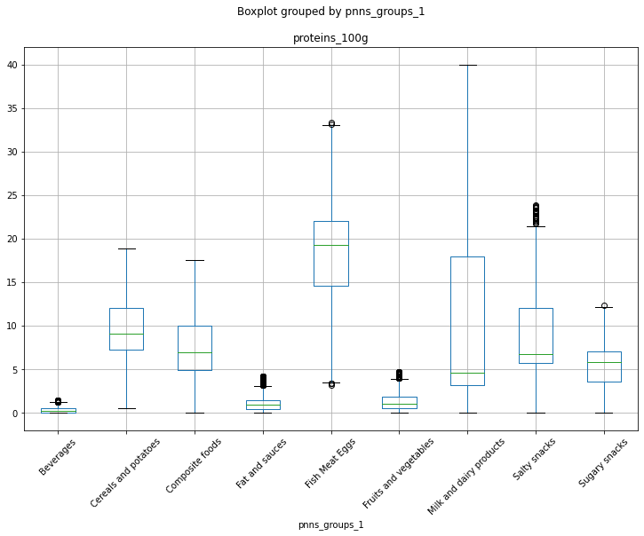

```python
#Create a boxplot
plt.figure(figsize=(15, 6))
df.boxplot('proteins_100g', by='pnns_groups_1', figsize=(12, 8))
plt.xticks(rotation='45')
plt.show()
```

### salt_100g

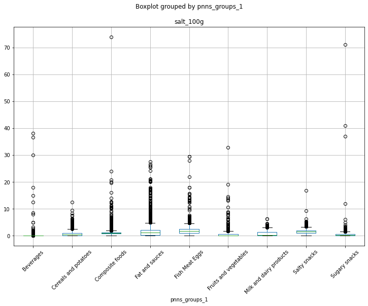

```python
#Create a boxplot
plt.figure(figsize=(15, 6))
df.boxplot('salt_100g', by='pnns_groups_1', figsize=(12, 8))
plt.xticks(rotation='45')
plt.show()
```

```python
q1 = df[df['pnns_groups_1'] == 'Beverages']['salt_100g'].quantile(.25)
q3 = df[df['pnns_groups_1'] == 'Beverages']['salt_100g'].quantile(.75)
IQR = q3 - q1
IQR
upper_boundary = q3 + (1.5 * IQR)
lower_boundary = q1 - (1.5 * IQR)
print("Upper Boundary using IQR  : {}".format(upper_boundary))
print("Lower Boundary using IQR  : {}".format(lower_boundary))

df_beverage = df[df['pnns_groups_1'] == 'Beverages']
df_beverage.loc[df_beverage['salt_100g'] > upper_boundary, 'salt_100g'] = np.nan

q1 = df[df['pnns_groups_1'] == 'Cereals and potatoes']['salt_100g'].quantile(.25)
q3 = df[df['pnns_groups_1'] == 'Cereals and potatoes']['salt_100g'].quantile(.75)
IQR = q3 - q1
IQR
upper_boundary = q3 + (1.5 * IQR)
lower_boundary = q1 - (1.5 * IQR)
print("Upper Boundary using IQR  : {}".format(upper_boundary))
print("Lower Boundary using IQR  : {}".format(lower_boundary))

df_cereals = df[df['pnns_groups_1'] == 'Cereals and potatoes']
df_cereals.loc[df_cereals['salt_100g'] > upper_boundary, 'salt_100g'] = np.nan
df_cereals.loc[df_cereals['salt_100g'] < lower_boundary, 'salt_100g'] = np.nan

q1 = df[df['pnns_groups_1'] == 'Composite foods']['salt_100g'].quantile(.25)
q3 = df[df['pnns_groups_1'] == 'Composite foods']['salt_100g'].quantile(.75)
IQR = q3 - q1
IQR
upper_boundary = q3 + (1.5 * IQR)
lower_boundary = q1 - (1.5 * IQR)
print("Upper Boundary using IQR  : {}".format(upper_boundary))
print("Lower Boundary using IQR  : {}".format(lower_boundary))

df_composite = df[df['pnns_groups_1'] == 'Composite foods']
df_composite.loc[df_composite['salt_100g'] > upper_boundary, 'salt_100g'] = np.nan

q1 = df[df['pnns_groups_1'] == 'Fat and sauces']['salt_100g'].quantile(.25)
q3 = df[df['pnns_groups_1'] == 'Fat and sauces']['salt_100g'].quantile(.75)
IQR = q3 - q1
IQR
upper_boundary = q3 + (1.5 * IQR)
lower_boundary = q1 - (1.5 * IQR)
print("Upper Boundary using IQR  : {}".format(upper_boundary))
print("Lower Boundary using IQR  : {}".format(lower_boundary))
df_fat = df[df['pnns_groups_1'] == 'Fat and sauces']
df_fat.loc[df_fat['salt_100g'] > upper_boundary, 'salt_100g'] = np.nan

q1 = df[df['pnns_groups_1'] == 'Fish Meat Eggs']['salt_100g'].quantile(.25)
q3 = df[df['pnns_groups_1'] == 'Fish Meat Eggs']['salt_100g'].quantile(.75)
IQR = q3 - q1
IQR
upper_boundary = q3 + (1.5 * IQR)
lower_boundary = q1 - (1.5 * IQR)
print("Upper Boundary using IQR  : {}".format(upper_boundary))
print("Lower Boundary using IQR  : {}".format(lower_boundary))

df_fish = df[df['pnns_groups_1'] == 'Fish Meat Eggs']
df_fish.loc[df_fish['salt_100g'] > upper_boundary, 'salt_100g'] = np.nan

q1 = df[df['pnns_groups_1'] == 'Salty snacks']['salt_100g'].quantile(.25)
q3 = df[df['pnns_groups_1'] == 'Salty snacks']['salt_100g'].quantile(.75)
IQR = q3 - q1
IQR
upper_boundary = q3 + (1.5 * IQR)
lower_boundary = q1 - (1.5 * IQR)
print("Upper Boundary using IQR  : {}".format(upper_boundary))
print("Lower Boundary using IQR  : {}".format(lower_boundary))

df_salty = df[df['pnns_groups_1'] == 'Salty snacks']
df_salty.loc[df_salty['salt_100g'] > upper_boundary, 'salt_100g'] = np.nan

q1 = df[df['pnns_groups_1'] == 'Milk and dairy products']['salt_100g'].quantile(.25)
q3 = df[df['pnns_groups_1'] == 'Milk and dairy products']['salt_100g'].quantile(.75)
IQR = q3 - q1
IQR
upper_boundary = q3 + (1.5 * IQR)
lower_boundary = q1 - (1.5 * IQR)
print("Upper Boundary using IQR  : {}".format(upper_boundary))
print("Lower Boundary using IQR  : {}".format(lower_boundary))

df_milk = df[df['pnns_groups_1'] == 'Milk and dairy products']
df_milk.loc[df_milk['salt_100g'] > upper_boundary, 'salt_100g'] = np.nan

q1 = df[df['pnns_groups_1'] == 'Fruits and vegetables']['salt_100g'].quantile(.25)
q3 = df[df['pnns_groups_1'] == 'Fruits and vegetables']['salt_100g'].quantile(.75)
IQR = q3 - q1
IQR
upper_boundary = q3 + (1.5 * IQR)
lower_boundary = q1 - (1.5 * IQR)
print("Upper Boundary using IQR  : {}".format(upper_boundary))
print("Lower Boundary using IQR  : {}".format(lower_boundary))

df_fruits = df[df['pnns_groups_1'] == 'Fruits and vegetables']
df_fruits.loc[df_fruits['salt_100g'] > upper_boundary, 'salt_100g'] = np.nan

q1 = df[df['pnns_groups_1'] == 'Sugary snacks']['salt_100g'].quantile(.25)
q3 = df[df['pnns_groups_1'] == 'Sugary snacks']['salt_100g'].quantile(.75)
IQR = q3 - q1
IQR
upper_boundary = q3 + (1.5 * IQR)
lower_boundary = q1 - (1.5 * IQR)
print("Upper Boundary using IQR  : {}".format(upper_boundary))
print("Lower Boundary using IQR  : {}".format(lower_boundary))

df_sugary= df[df['pnns_groups_1'] == 'Sugary snacks']
df_sugary.loc[df_sugary['salt_100g'] > upper_boundary, 'salt_100g'] = np.nan
df_sugary.loc[df_sugary['salt_100g'] < lower_boundary, 'salt_100g'] = np.nan
```

```
Upper Boundary using IQR  : 0.075
Lower Boundary using IQR  : -0.045
Upper Boundary using IQR  : 2.545775
Lower Boundary using IQR  : -1.495465
Upper Boundary using IQR  : 1.97
Lower Boundary using IQR  : -0.030000000000000027
Upper Boundary using IQR  : 4.885225
Lower Boundary using IQR  : -2.5279350000000003
Upper Boundary using IQR  : 4.6715575000000005
Lower Boundary using IQR  : -1.1192625
Upper Boundary using IQR  : 3.3108750000000002
Lower Boundary using IQR  : -0.30652499999999994
Upper Boundary using IQR  : 3.0976
Lower Boundary using IQR  : -1.6960000000000002
Upper Boundary using IQR  : 1.71
Lower Boundary using IQR  : -1.01
Upper Boundary using IQR  : 1.5
Lower Boundary using IQR  : -0.8200000000000002
```

```python
df = pd.concat([df_beverage, df_cereals, df_composite, df_fat,
               df_fish, df_salty, df_fruits, df_milk, df_sugary], axis=0)
```

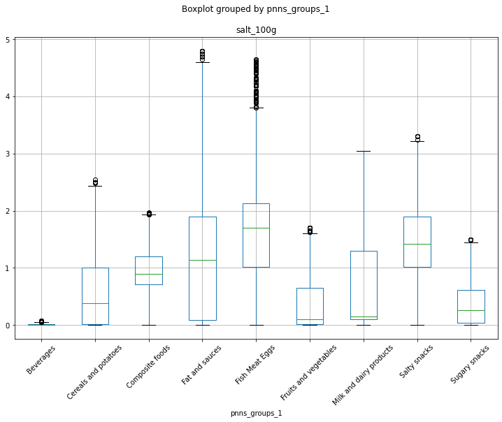

```python
#Create a boxplot
plt.figure(figsize=(15, 6))
df.boxplot('salt_100g', by='pnns_groups_1', figsize=(12, 8))
plt.xticks(rotation='45')
plt.show()
```

## Energy_100G

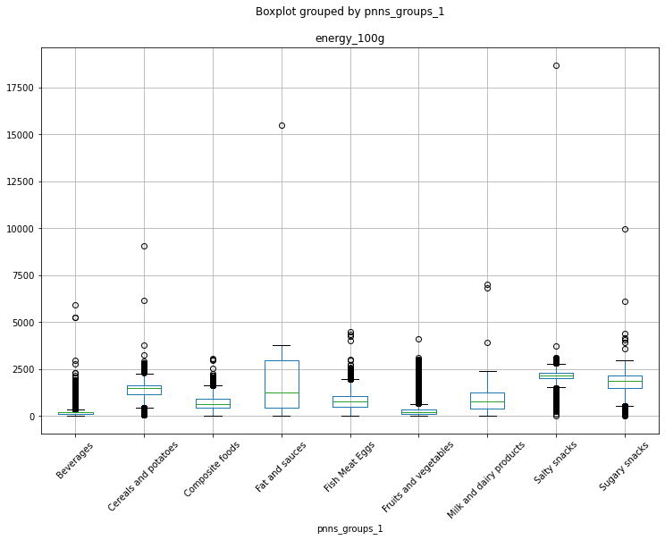

```python
#Create a boxplot
plt.figure(figsize=(15, 6))
df.boxplot('energy_100g', by='pnns_groups_1', figsize=(12, 8))
plt.xticks(rotation='45')
plt.show()
```

```python
q1 = df[df['pnns_groups_1'] == 'Beverages']['energy_100g'].quantile(.25)
q3 = df[df['pnns_groups_1'] == 'Beverages']['energy_100g'].quantile(.75)
IQR = q3 - q1
IQR
upper_boundary = q3 + (1.5 * IQR)
lower_boundary = q1 - (1.5 * IQR)
print("Upper Boundary using IQR  : {}".format(upper_boundary))
print("Lower Boundary using IQR  : {}".format(lower_boundary))

df_beverage = df[df['pnns_groups_1'] == 'Beverages']
df_beverage.loc[df_beverage['energy_100g'] > upper_boundary, 'energy_100g'] = np.nan

q1 = df[df['pnns_groups_1'] == 'Cereals and potatoes']['energy_100g'].quantile(.25)
q3 = df[df['pnns_groups_1'] == 'Cereals and potatoes']['energy_100g'].quantile(.75)
IQR = q3 - q1
IQR
upper_boundary = q3 + (1.5 * IQR)
lower_boundary = q1 - (1.5 * IQR)
print("Upper Boundary using IQR  : {}".format(upper_boundary))
print("Lower Boundary using IQR  : {}".format(lower_boundary))

df_cereals = df[df['pnns_groups_1'] == 'Cereals and potatoes']
df_cereals.loc[df_cereals['energy_100g'] > upper_boundary, 'energy_100g'] = np.nan
df_cereals.loc[df_cereals['energy_100g'] < lower_boundary, 'energy_100g'] = np.nan

q1 = df[df['pnns_groups_1'] == 'Composite foods']['energy_100g'].quantile(.25)
q3 = df[df['pnns_groups_1'] == 'Composite foods']['energy_100g'].quantile(.75)
IQR = q3 - q1
IQR
upper_boundary = q3 + (1.5 * IQR)
lower_boundary = q1 - (1.5 * IQR)
print("Upper Boundary using IQR  : {}".format(upper_boundary))
print("Lower Boundary using IQR  : {}".format(lower_boundary))

df_composite = df[df['pnns_groups_1'] == 'Composite foods']
df_composite.loc[df_composite['energy_100g'] > upper_boundary, 'energy_100g'] = np.nan

q1 = df[df['pnns_groups_1'] == 'Fat and sauces']['energy_100g'].quantile(.25)
q3 = df[df['pnns_groups_1'] == 'Fat and sauces']['energy_100g'].quantile(.75)
IQR = q3 - q1
IQR
upper_boundary = q3 + (1.5 * IQR)
lower_boundary = q1 - (1.5 * IQR)
print("Upper Boundary using IQR  : {}".format(upper_boundary))
print("Lower Boundary using IQR  : {}".format(lower_boundary))
df_fat = df[df['pnns_groups_1'] == 'Fat and sauces']
df_fat.loc[df_fat['energy_100g'] > upper_boundary, 'energy_100g'] = np.nan

q1 = df[df['pnns_groups_1'] == 'Fish Meat Eggs']['energy_100g'].quantile(.25)
q3 = df[df['pnns_groups_1'] == 'Fish Meat Eggs']['energy_100g'].quantile(.75)
IQR = q3 - q1
IQR
upper_boundary = q3 + (1.5 * IQR)
lower_boundary = q1 - (1.5 * IQR)
print("Upper Boundary using IQR  : {}".format(upper_boundary))
print("Lower Boundary using IQR  : {}".format(lower_boundary))

df_fish = df[df['pnns_groups_1'] == 'Fish Meat Eggs']
df_fish.loc[df_fish['energy_100g'] > upper_boundary, 'energy_100g'] = np.nan

q1 = df[df['pnns_groups_1'] == 'Salty snacks']['energy_100g'].quantile(.25)
q3 = df[df['pnns_groups_1'] == 'Salty snacks']['energy_100g'].quantile(.75)
IQR = q3 - q1
IQR
upper_boundary = q3 + (1.5 * IQR)
lower_boundary = q1 - (1.5 * IQR)
print("Upper Boundary using IQR  : {}".format(upper_boundary))
print("Lower Boundary using IQR  : {}".format(lower_boundary))

df_salty = df[df['pnns_groups_1'] == 'Salty snacks']
df_salty.loc[df_salty['energy_100g'] > upper_boundary, 'energy_100g'] = np.nan

q1 = df[df['pnns_groups_1'] == 'Milk and dairy products']['energy_100g'].quantile(.25)
q3 = df[df['pnns_groups_1'] == 'Milk and dairy products']['energy_100g'].quantile(.75)
IQR = q3 - q1
IQR
upper_boundary = q3 + (1.5 * IQR)
lower_boundary = q1 - (1.5 * IQR)
print("Upper Boundary using IQR  : {}".format(upper_boundary))
print("Lower Boundary using IQR  : {}".format(lower_boundary))

df_milk = df[df['pnns_groups_1'] == 'Milk and dairy products']
df_milk.loc[df_milk['energy_100g'] > upper_boundary, 'energy_100g'] = np.nan

q1 = df[df['pnns_groups_1'] == 'Fruits and vegetables']['energy_100g'].quantile(.25)
q3 = df[df['pnns_groups_1'] == 'Fruits and vegetables']['energy_100g'].quantile(.75)
IQR = q3 - q1
IQR
upper_boundary = q3 + (1.5 * IQR)
lower_boundary = q1 - (1.5 * IQR)
print("Upper Boundary using IQR  : {}".format(upper_boundary))
print("Lower Boundary using IQR  : {}".format(lower_boundary))

df_fruits = df[df['pnns_groups_1'] == 'Fruits and vegetables']
df_fruits.loc[df_fruits['salt_100g'] > upper_boundary, 'energy_100g'] = np.nan

q1 = df[df['pnns_groups_1'] == 'Sugary snacks']['energy_100g'].quantile(.25)
q3 = df[df['pnns_groups_1'] == 'Sugary snacks']['energy_100g'].quantile(.75)
IQR = q3 - q1
IQR
upper_boundary = q3 + (1.5 * IQR)
lower_boundary = q1 - (1.5 * IQR)
print("Upper Boundary using IQR  : {}".format(upper_boundary))
print("Lower Boundary using IQR  : {}".format(lower_boundary))

df_sugary= df[df['pnns_groups_1'] == 'Sugary snacks']
df_sugary.loc[df_sugary['energy_100g'] > upper_boundary, 'energy_100g'] = np.nan
df_sugary.loc[df_sugary['energy_100g'] < lower_boundary, 'energy_100g'] = np.nan
```

```
Upper Boundary using IQR  : 363.5
Lower Boundary using IQR  : -24.5
Upper Boundary using IQR  : 2303.125
Lower Boundary using IQR  : 460.125
Upper Boundary using IQR  : 1618.0
Lower Boundary using IQR  : -254.0
Upper Boundary using IQR  : 6777.25
Lower Boundary using IQR  : -3348.75
Upper Boundary using IQR  : 1950.5
Lower Boundary using IQR  : -373.5
Upper Boundary using IQR  : 2799.5
Lower Boundary using IQR  : 1507.5
Upper Boundary using IQR  : 2567.375
Lower Boundary using IQR  : -905.625
Upper Boundary using IQR  : 654.65
Lower Boundary using IQR  : -202.39
Upper Boundary using IQR  : 3118.5
Lower Boundary using IQR  : 546.5
```

```python
df = pd.concat([df_beverage, df_cereals, df_composite, df_fat,
               df_fish, df_salty, df_fruits, df_milk, df_sugary], axis=0)
```

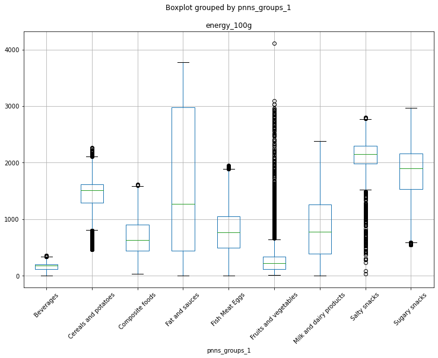

```python
#Create a boxplot
plt.figure(figsize=(15, 6))
df.boxplot('energy_100g', by='pnns_groups_1', figsize=(12, 8))
plt.xticks(rotation='45')
plt.show()
```

```python
df[df['energy_100g']>3800]
```

|  | product_name | fat_100g | sugars_100g | energy_100g | carbohydrates_100g | saturated-fat_100g | fiber_100g | proteins_100g | salt_100g | nutrition-score-fr_100g | pnns_groups_1 | nutrition_grade_fr |
| --- | --- | --- | --- | --- | --- | --- | --- | --- | --- | --- | --- | --- |
| 184458 | Pruneaux d'Agen Dénoyautés | 0.2 | NaN | 4117.0 | NaN | 0.1 | 0.0 | 2.4 | 0.01 | 12.0 | Fruits and vegetables | d |

## Feature Product name

```python
df['product_name'].isna().sum()
```

```
235
```

### Drop NaN

```python
df.dropna(subset=['product_name'],inplace=True)
```

## Feature nutrition-score-fr_100g et Nutrition grade

Le nutrition-score-fr_100g doit etre > 40 et inférieure -15

- Nutri-Score A : -15 à -1
- Nutri-Score B : 0 à 2
- Nutri-Score C : 3 à 10
- Nutri-Score D : 11 à 18
- Nutri-Score E : 19 à 40

```python
df[df['nutrition-score-fr_100g'] >40]
```

|  | product_name | fat_100g | sugars_100g | energy_100g | carbohydrates_100g | saturated-fat_100g | fiber_100g | proteins_100g | salt_100g | nutrition-score-fr_100g | pnns_groups_1 | nutrition_grade_fr |
| --- | --- | --- | --- | --- | --- | --- | --- | --- | --- | --- | --- | --- |

```python
df[df['nutrition-score-fr_100g'] <-15]
```

|  | product_name | fat_100g | sugars_100g | energy_100g | carbohydrates_100g | saturated-fat_100g | fiber_100g | proteins_100g | salt_100g | nutrition-score-fr_100g | pnns_groups_1 | nutrition_grade_fr |
| --- | --- | --- | --- | --- | --- | --- | --- | --- | --- | --- | --- | --- |

Vérififions que les **nutrition-score-fr_100g** et les **nutrition_grade_fr** sont correctement associés. Pour cela, croisez les variables dans un même tableau.

- Nutri-Score A : -15 à -1
- Nutri-Score B : 0 à 2
- Nutri-Score C : 3 à 10
- Nutri-Score D : 11 à 18
- Nutri-Score E : 19 à 40

```python
pd.crosstab(df['nutrition-score-fr_100g'], df['nutrition_grade_fr'])
```

| nutrition_grade_fr nutrition-score-fr_100g | a | b | c | d | e |
| --- | --- | --- | --- | --- | --- |
| -15.0 | 1 | 0 | 0 | 0 | 0 |
| -14.0 | 4 | 0 | 0 | 0 | 0 |
| -13.0 | 15 | 0 | 0 | 0 | 0 |
| -12.0 | 28 | 0 | 0 | 0 | 0 |
| -11.0 | 59 | 0 | 0 | 0 | 0 |
| -10.0 | 92 | 0 | 0 | 0 | 0 |
| -9.0 | 127 | 0 | 0 | 0 | 0 |
| -8.0 | 185 | 1 | 0 | 0 | 0 |
| -7.0 | 285 | 0 | 0 | 0 | 0 |
| -6.0 | 935 | 5 | 0 | 0 | 0 |
| -5.0 | 1042 | 13 | 0 | 0 | 0 |
| -4.0 | 948 | 39 | 0 | 0 | 0 |
| -3.0 | 839 | 11 | 0 | 0 | 0 |
| -2.0 | 1034 | 24 | 0 | 0 | 0 |
| -1.0 | 1324 | 12 | 0 | 0 | 0 |
| 0.0 | 42 | 1904 | 0 | 0 | 0 |
| 1.0 | 7 | 1794 | 0 | 0 | 0 |
| 2.0 | 1 | 1648 | 365 | 0 | 0 |
| 3.0 | 0 | 0 | 1804 | 0 | 0 |
| 4.0 | 1 | 0 | 1699 | 0 | 0 |
| 5.0 | 0 | 0 | 1218 | 0 | 0 |
| 6.0 | 1 | 0 | 576 | 219 | 0 |
| 7.0 | 0 | 0 | 521 | 113 | 0 |
| 8.0 | 0 | 0 | 652 | 133 | 0 |
| 9.0 | 0 | 0 | 690 | 167 | 0 |
| 10.0 | 1 | 0 | 819 | 0 | 171 |
| 11.0 | 0 | 0 | 0 | 1612 | 118 |
| 12.0 | 0 | 0 | 0 | 1368 | 140 |
| 13.0 | 0 | 0 | 0 | 1293 | 260 |
| 14.0 | 0 | 0 | 0 | 1694 | 156 |
| 15.0 | 0 | 0 | 0 | 1304 | 223 |
| 16.0 | 1 | 0 | 0 | 989 | 104 |
| 17.0 | 0 | 0 | 0 | 916 | 84 |
| 18.0 | 0 | 0 | 0 | 818 | 52 |
| 19.0 | 0 | 0 | 0 | 0 | 1101 |
| 20.0 | 0 | 0 | 0 | 0 | 1004 |
| 21.0 | 0 | 0 | 0 | 0 | 721 |
| 22.0 | 0 | 0 | 0 | 0 | 566 |
| 23.0 | 0 | 0 | 0 | 0 | 523 |
| 24.0 | 0 | 0 | 0 | 0 | 507 |
| 25.0 | 0 | 0 | 0 | 0 | 591 |
| 26.0 | 0 | 0 | 0 | 0 | 561 |
| 27.0 | 0 | 0 | 0 | 0 | 280 |
| 28.0 | 0 | 0 | 0 | 0 | 147 |
| 29.0 | 0 | 0 | 0 | 0 | 27 |
| 30.0 | 0 | 0 | 0 | 0 | 13 |
| 31.0 | 0 | 0 | 0 | 0 | 7 |
| 32.0 | 0 | 0 | 0 | 0 | 14 |
| 33.0 | 0 | 0 | 0 | 0 | 5 |
| 34.0 | 0 | 0 | 0 | 0 | 1 |
| 35.0 | 0 | 0 | 0 | 0 | 4 |
| 40.0 | 0 | 0 | 0 | 0 | 1 |

On peut observer des erreurs pour certain produit, nous allons considerer que le nutrition-score-fr_100g est correct mais le grade est érroné

## Création de la feature "nutrition_grade_fr"

- Nutri-Score A : -15 à -1
- Nutri-Score B : 0 à 2
- Nutri-Score C : 3 à 10
- Nutri-Score D : 11 à 18
- Nutri-Score E : 19 à 40

```python
def nutrition_grade(x):
    if x >=-15 and x <=-1 :
        return 'A'
    elif x >=-0 and x <=2 :
        return 'B'
    elif x >=3 and x <=10:
        return 'C'
    elif x >=11 and x <=18 :
        return 'D'
    else:
         return 'E'
```

```python
df["nutrition_grade_fr"] = df['nutrition-score-fr_100g'].apply(nutrition_grade)
```

```python
pd.crosstab(df['nutrition-score-fr_100g'], df['nutrition_grade_fr'])
```

| nutrition_grade_fr nutrition-score-fr_100g | A | B | C | D | E |
| --- | --- | --- | --- | --- | --- |
| -15.0 | 1 | 0 | 0 | 0 | 0 |
| -14.0 | 4 | 0 | 0 | 0 | 0 |
| -13.0 | 15 | 0 | 0 | 0 | 0 |
| -12.0 | 28 | 0 | 0 | 0 | 0 |
| -11.0 | 59 | 0 | 0 | 0 | 0 |
| -10.0 | 92 | 0 | 0 | 0 | 0 |
| -9.0 | 127 | 0 | 0 | 0 | 0 |
| -8.0 | 186 | 0 | 0 | 0 | 0 |
| -7.0 | 285 | 0 | 0 | 0 | 0 |
| -6.0 | 940 | 0 | 0 | 0 | 0 |
| -5.0 | 1055 | 0 | 0 | 0 | 0 |
| -4.0 | 987 | 0 | 0 | 0 | 0 |
| -3.0 | 850 | 0 | 0 | 0 | 0 |
| -2.0 | 1058 | 0 | 0 | 0 | 0 |
| -1.0 | 1336 | 0 | 0 | 0 | 0 |
| 0.0 | 0 | 1946 | 0 | 0 | 0 |
| 1.0 | 0 | 1801 | 0 | 0 | 0 |
| 2.0 | 0 | 2014 | 0 | 0 | 0 |
| 3.0 | 0 | 0 | 1804 | 0 | 0 |
| 4.0 | 0 | 0 | 1700 | 0 | 0 |
| 5.0 | 0 | 0 | 1218 | 0 | 0 |
| 6.0 | 0 | 0 | 796 | 0 | 0 |
| 7.0 | 0 | 0 | 634 | 0 | 0 |
| 8.0 | 0 | 0 | 785 | 0 | 0 |
| 9.0 | 0 | 0 | 857 | 0 | 0 |
| 10.0 | 0 | 0 | 991 | 0 | 0 |
| 11.0 | 0 | 0 | 0 | 1730 | 0 |
| 12.0 | 0 | 0 | 0 | 1508 | 0 |
| 13.0 | 0 | 0 | 0 | 1553 | 0 |
| 14.0 | 0 | 0 | 0 | 1850 | 0 |
| 15.0 | 0 | 0 | 0 | 1527 | 0 |
| 16.0 | 0 | 0 | 0 | 1094 | 0 |
| 17.0 | 0 | 0 | 0 | 1000 | 0 |
| 18.0 | 0 | 0 | 0 | 870 | 0 |
| 19.0 | 0 | 0 | 0 | 0 | 1101 |
| 20.0 | 0 | 0 | 0 | 0 | 1004 |
| 21.0 | 0 | 0 | 0 | 0 | 721 |
| 22.0 | 0 | 0 | 0 | 0 | 566 |
| 23.0 | 0 | 0 | 0 | 0 | 523 |
| 24.0 | 0 | 0 | 0 | 0 | 507 |
| 25.0 | 0 | 0 | 0 | 0 | 591 |
| 26.0 | 0 | 0 | 0 | 0 | 561 |
| 27.0 | 0 | 0 | 0 | 0 | 280 |
| 28.0 | 0 | 0 | 0 | 0 | 147 |
| 29.0 | 0 | 0 | 0 | 0 | 27 |
| 30.0 | 0 | 0 | 0 | 0 | 13 |
| 31.0 | 0 | 0 | 0 | 0 | 7 |
| 32.0 | 0 | 0 | 0 | 0 | 14 |
| 33.0 | 0 | 0 | 0 | 0 | 5 |
| 34.0 | 0 | 0 | 0 | 0 | 1 |
| 35.0 | 0 | 0 | 0 | 0 | 4 |
| 40.0 | 0 | 0 | 0 | 0 | 1 |

### Imputation données manquantes Feature 'fiber_100g '

```python
df['fiber_100g'] = df['fiber_100g'].fillna(0)
```

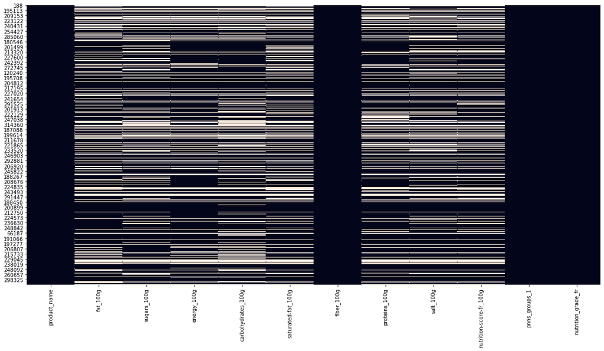

```python
plt.figure(figsize=(20,10))
sns.heatmap(df.isna(), cbar=False)
```

### Produits dupliqués

Visualisation des données 'product_name' dupliquées

```python
df['product_name'].value_counts()
```

```
Huile d'olive vierge extra          53
Moutarde de Dijon                   43
Mayonnaise                          39
Orange                              39
Framboises                          36
                                    ..
Jambon cru fumé au bois de hêtre     1
Sans sucres Parfum Grenadine         1
Epinards hachés en portions          1
Les Cocottes Poulet au Citron        1
Yop, Parfum Framboise                1
Name: product_name, Length: 41048, dtype: int64
```

```python
df_duplicated = df.drop_duplicates(subset="product_name",
                                   keep=False)

print(
    f"Il y a un total de {len(df) - len(df_duplicated)} lignes produits dupliquées.")
```

```
Il y a un total de 13625 lignes produits dupliquées.
```

```python
df.shape
df_duplicated.shape
```

```
(37094, 12)
```

```python
df = df_duplicated.groupby("product_name")[["fat_100g", "sugars_100g", "energy_100g", "carbohydrates_100g",
                                             "saturated-fat_100g", "fiber_100g", "proteins_100g", "salt_100g",
                                            "nutrition-score-fr_100g"]].agg(lambda x: x.median())

df
```

| product_name | fat_100g | sugars_100g | energy_100g | carbohydrates_100g | saturated-fat_100g | fiber_100g | proteins_100g | salt_100g | nutrition-score-fr_100g |
| --- | --- | --- | --- | --- | --- | --- | --- | --- | --- |
| Bridelight 3% Les carrés fondants goût Emmental | 3.0 | 8.5 | 477.0 | 8.5 | 2.0 | 0.0 | 13.0 | 2.000000 | 6.0 |
| 100 % Pur Jus Pomme | 0.0 | 9.7 | 179.0 | 10.0 | 0.0 | 0.0 | 0.5 | 0.030000 | 3.0 |
| 18 marrons glacés | 0.8 | 56.0 | 1378.0 | 76.0 | 0.1 | 4.8 | 0.8 | 0.050038 | 9.0 |
| 6 carrés fourrés, saveur amande | 14.3 | 34.3 | 1636.0 | 59.1 | 6.2 | 2.6 | 5.5 | 0.530000 | 16.0 |
| Barre marbrée cacao | 22.0 | NaN | 1800.0 | 52.0 | NaN | 0.0 | 6.0 | NaN | NaN |
| ... | ... | ... | ... | ... | ... | ... | ... | ... | ... |
| œufs frais de poules élevées en plein air issus de l'agriculture biologique | 10.0 | 0.7 | 586.0 | 0.7 | 2.7 | 0.0 | 12.0 | 0.320000 | -1.0 |
| 寿司米 | 0.4 | 0.2 | 1504.0 | 80.4 | 0.1 | 1.0 | 6.7 | 0.013005 | -1.0 |
| 고등어캔 | NaN | NaN | NaN | NaN | NaN | 0.0 | NaN | NaN | NaN |
| 쌀떡 | 0.5 | 2.0 | 983.0 | NaN | 0.0 | 0.0 | 3.0 | 0.177800 | -4.0 |
| 칠성사이다 | 0.0 | 8.4 | 184.0 | 10.8 | 0.0 | 0.0 | 0.0 | 0.040000 | 13.0 |

37094 rows × 9 columns

```python
df.reset_index(inplace=True)
```

### KNNImputer sur les valeurs quantitatives

```python
# import the KNNimputer class
from sklearn.impute import KNNImputer
```

```python
X=df.select_dtypes(include=np.number)
```

```python
imputer = KNNImputer(n_neighbors = 2)
imputed = imputer.fit_transform(X)
df_imputed = pd.DataFrame(imputed, columns=X.columns)
df_imputed.head()
```

|  | fat_100g | sugars_100g | energy_100g | carbohydrates_100g | saturated-fat_100g | fiber_100g | proteins_100g | salt_100g | nutrition-score-fr_100g |
| --- | --- | --- | --- | --- | --- | --- | --- | --- | --- |
| 0 | 3.0 | 8.5 | 477.0 | 8.5 | 2.000 | 0.0 | 13.0 | 2.000000 | 6.0 |
| 1 | 0.0 | 9.7 | 179.0 | 10.0 | 0.000 | 0.0 | 0.5 | 0.030000 | 3.0 |
| 2 | 0.8 | 56.0 | 1378.0 | 76.0 | 0.100 | 4.8 | 0.8 | 0.050038 | 9.0 |
| 3 | 14.3 | 34.3 | 1636.0 | 59.1 | 6.200 | 2.6 | 5.5 | 0.530000 | 16.0 |
| 4 | 22.0 | 32.1 | 1800.0 | 52.0 | 0.025 | 0.0 | 6.0 | 0.000000 | 0.0 |

```python
#check KNN imputation worked
df_imputed.isna().sum()
```

```
fat_100g                   0
sugars_100g                0
energy_100g                0
carbohydrates_100g         0
saturated-fat_100g         0
fiber_100g                 0
proteins_100g              0
salt_100g                  0
nutrition-score-fr_100g    0
dtype: int64
```

```python
df_product_name = df['product_name']
```

```python
df = pd.concat([df_product_name, df_imputed], axis=1)
```

```python
df_after = df_after[['product_name', 'pnns_groups_1']]
```

```python
df = pd.merge(df, df_after, how='inner', on='product_name')
```

### KNNImputer sur les valeurs qualitatives

```python
#Encodage
df['cat pnns']=df.pnns_groups_1.astype('category').cat.codes
```

```python
X=df.select_dtypes(include=np.number)
```

```python
imputer = KNNImputer(n_neighbors = 2)
imputed = imputer.fit_transform(X)
df_imputed = pd.DataFrame(imputed, columns=X.columns)
df_imputed.head()
```

|  | fat_100g | sugars_100g | energy_100g | carbohydrates_100g | saturated-fat_100g | fiber_100g | proteins_100g | salt_100g | nutrition-score-fr_100g | cat pnns |
| --- | --- | --- | --- | --- | --- | --- | --- | --- | --- | --- |
| 0 | 3.0 | 8.5 | 477.0 | 8.5 | 2.000 | 0.0 | 13.0 | 2.000000 | 6.0 | 6.0 |
| 1 | 0.0 | 9.7 | 179.0 | 10.0 | 0.000 | 0.0 | 0.5 | 0.030000 | 3.0 | 0.0 |
| 2 | 0.8 | 56.0 | 1378.0 | 76.0 | 0.100 | 4.8 | 0.8 | 0.050038 | 9.0 | 8.0 |
| 3 | 14.3 | 34.3 | 1636.0 | 59.1 | 6.200 | 2.6 | 5.5 | 0.530000 | 16.0 | 8.0 |
| 4 | 22.0 | 32.1 | 1800.0 | 52.0 | 0.025 | 0.0 | 6.0 | 0.000000 | 0.0 | 8.0 |

```python
#check KNN imputation worked
df_imputed.isna().sum()
```

```
fat_100g                   0
sugars_100g                0
energy_100g                0
carbohydrates_100g         0
saturated-fat_100g         0
fiber_100g                 0
proteins_100g              0
salt_100g                  0
nutrition-score-fr_100g    0
cat pnns                   0
dtype: int64
```

```python
df_product_name = df['product_name']
```

```python
df = pd.concat([df_product_name, df_imputed], axis=1)
```

```python
df_after = df_after[['product_name', 'pnns_groups_1']]
```

```python
df = pd.merge(df, df_after, how='inner', on='product_name')
```

```python
df.isna().sum()
```

```
product_name                  0
fat_100g                      0
sugars_100g                   0
energy_100g                   0
carbohydrates_100g            0
saturated-fat_100g            0
fiber_100g                    0
proteins_100g                 0
salt_100g                     0
nutrition-score-fr_100g       0
cat pnns                      0
pnns_groups_1              3716
dtype: int64
```

```python
df['cat pnns'].value_counts()
```

```
 8.0    7672
 6.0    5016
 4.0    4987
 2.0    4978
 0.0    4445
 1.0    4352
-1.0    3716
 5.0    2987
 3.0    2344
 7.0    1479
Name: cat pnns, dtype: int64
```

```python
df['pnns_groups_1'].value_counts()
```

```
Sugary snacks              7672
Milk and dairy products    5016
Fish Meat Eggs             4987
Composite foods            4978
Beverages                  4445
Cereals and potatoes       4352
Fruits and vegetables      2987
Fat and sauces             2344
Salty snacks               1479
Name: pnns_groups_1, dtype: int64
```

### Création de la feature "pnns groupe"

- Groupe 0 : Beverages
- Groupe 1 : Cereals and potatoes
- Groupe 2 : Composite foods
- Groupe 3 : Fat and sauces
- Groupe 4 : Fish Meat Eggs
- Groupe 5 : Fruits and vegetables
- Groupe 6 : Milk and dairy products
- Groupe 7 : Salty snacks
- Groupe 8 : Sugary snacks